# 15 Régression linéaire simple: Inférences

### 15.7.7 Test de signification global de la régression

À ce stade, nous sommes en mesure d’établir l’équation de la droite de régression et de quantifier certains de ses caractéristiques fondamentales. Ces opérations nous ont permis de **décrire** la relation entre X et Y. Il nous reste à examiner les stratégies inférentielles qui nous permettront d’estimer les paramètres ou d’effectuer des tests d’hypothèse les concernant.

Dans un contexte de régression linéaire simple, il sera approprié d’estimer $\beta_0$, $\beta_1$, et $\rho_{xy}$, entre autres. On pourra également considérer des vérifications d’hypothèses telles que:

- $H_0:\beta_{0}=0$
- $H_0:\beta_{1}=0$
- $H_0:\rho_{xy}=0$

Notons que les hypothèses concernant $\beta_1$ et $\rho_{xy}$ sont équivalentes, en régression linéaire simple. Si la corrélation est statistiquement significative, le coefficient de régression le sera aussi.

L’ensemble des résultats obtenus jusqu’ici peuvent se résumer dans un tableau que l’on rencontre fréquemment dans les rapports de recherche: le tableau de l’**analyse de la variance**. La figure Figure 15.33 représente une forme très fréquemment rencontrée dans la littérature scientifique:

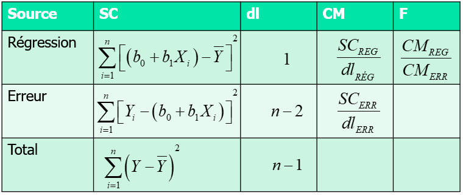

Figure 15.33: Tableau de l’analyse de la variance (Régression)

Dans la première colonne, on retrouve les **Sources de variation** que l’on connait déjà: régression, erreur et total. La deuxième colonne contient les **Sommes des Carrés** pour chacune des sources de variation. Rappelons que $SC_{Total} = SC_{Régression}+SC_{Erreur}$.

La troisième colonne contient le nombre de degrés de liberté associè à chacune des sources. $SC_{Régression}$ est associé à un nombre de degrés de liberté égal au nombre de variables indépendantes (un, dans le cas de la régression linéaire simple). $SC_{Résidu}$ est associé à la taille de l’échantillon, moins le nombre de variables, incluant la variable dépendante: $n-2$ dans le cas présent. Et pour $SC_{Total}$, qui n’est que le numérateur de la variance, le nombre de degrés de liberté est $n-1$. Notons que $dl_{Régression}+dl_{Résidu}=dl_{Total}$.

La quatrième colonne du tableau correspond aux variances associées à chacune des sources de variation. Ces variances sont appelées **Carrés Moyens** dans le présent contexte. Ils sont obtenus simplement en divisant la somme des carrés par le nombre de degrés de liberté correspondant. Le carré moyen pour la régression est une estimation de la variance des écarts entre les valeurs prédites et la moyenne de la variable dépendante. Le carré moyen résiduel est une estimation de la variance de Y, en contrôlant l’impact de X sur cette variable.

Bref, on obtient deux estimations de variances: la première réflétant l’impact de la variable indépendante sur la variable dépendante, et la seconde reflétant la variation aléatoire, indépendante de la VI. La question que l’on est amené à investiguer à ce point est: ‘**Est-ce que l’utilisation de l’information contenue dans la variable indépendante nous permet d’expliquer la variable dépendante mieux que si on négligeait cette information?**’ Pour répondre à cette question, un rapport entre les deux carrés moyens est tout indiqué: si la VI ne nous apprend rien, sa contribution sera équivalente au hasard et $CM_{Régression} = CM_{Résidu}$, ce qui se traduira par un rapport $F=1$. Plus la contribution de la VI à l’explication de la VD sera importante, plus $F$ s’éloignera de 1.0. Ceci rappellera le rapport F défini et utilisé dans un test d’hypothèse portant sur deux échantillons indépendants.

La distribution F, avec 1 et $n-2$ degrés de liberté nous permettra d’obtenir la probabilité d’obtenir une valeur égale ou supérieure au F observé, en supposant que $H_0$ est vraie.

Sous R, les commandes suivantes produisent l’analyse de la régression et le tableau de l’analyse de la variance qui, pour l’exemple précédent (section Section 15.7.5.1), est reproduit dans le tableau Table 15.11).

```r
reg <- lm(Y ~ X)
aov <- anova(reg)
aovtbl <- data.frame(c("Régression", "Erreur", "Total"),
                     c(aov$`Sum Sq`, sum(aov$`Sum Sq`)),
                     c(aov$Df, sum(aov$Df)),
                     c(aov$`Mean Sq`, NA),
                     c(aov$`F value`, NA),
                     c(aov$`Pr(>F)`, NA))
colnames(aovtbl) <- c("Source", "SC", "dl", "CM", "F", "p")
options(knitr.kable.NA = '')
  aovtbl %>%
    kbl(digits=3, booktabs=TRUE) %>%
    kable_styling(bootstrap_options = c("striped", "hover", "condensed"),
                  full_width=FALSE) %>%
    column_spec(1, bold=TRUE, border_left=TRUE, border_right=TRUE)
```

Table 15.11: Tableau de l’Analyse de la Variance, suite à une régression linéaire simple.

| Source | SC | dl | CM | F | p |
| --- | --- | --- | --- | --- | --- |
| Régression | 944.539 | 1 | 944.539 | 13.525 | 0.001 |
| Erreur | 1955.461 | 28 | 69.838 |  |  |
| Total | 2900.000 | 29 |  |  |  |

La probabilité qu’un rapport F observé égal ou supérieur à 13.525 est faible (p = 0.001), en supposant que $H_0$ soit vraie. Ce résultat suggère que:

- La corrélation entre X et Y ($\rho_{XY}$) est significativement différente de 0 au niveau de la population;
- Le coefficient de régression ($\beta_1$) est significativement différente de 0 au niveau de la population;
- La variable indépendante permet d’expliquer une portion significative de la variabilité de la variable dépendante.

### 15.7.8 Test de signification des coefficients

Chacun des paramètres d’un modèle de régression peut être soumis à un test d’hypothèse. Ces tests seront davantage importants pour l’examen de modèles plus complexes, mais il convient d’en élaborer dès maintenant les procédures pour les coefficients $b_1$ et $b_0$.

Nous avons présenté les distributions d’échantillonnage de ces deux coefficients au début de ce chapitre, constatant qu’elles sont Gaussiennes, avec une moyenne égale aux paramètres correspondants au niveau de la population, et une certaine dispersion quantifiée par l’erreur-standard de $b_0$ et de $b_1$. Formellement, ces erreurs-standards sont définis par les équations Équation 15.29 et Équation 15.30:

$$s_{b_1}=\frac{s_{yx}}{\sqrt{\sum(X-\bar X)^2}} \tag{15.29}$$

$$s_{b_0}=s_{yx}\sqrt{\frac{\sum X^2}{\sqrt{n\sum(X-\bar X)^2}}} \tag{15.30}$$

De ces équations, il ressort que les erreurs-standards dépendent fortement de la dispersion de la variable indépendante: plus $\sum(X-\bar X)^2$ est grande, plus les erreurs-standards sont petites.

Connaissant les erreurs-standards des coefficients, on peut estimer les paramètres correspondants au niveau de la population (équations Équation 15.31 et Équation 15.32), ou effectuer une vérification d’hypothèse (équations Équation 15.33 et Équation 15.34):

#### 15.7.8.1 Estimation (Intervalle de confiance)

Estimation de $\beta_0$:
$$b_0\pm t_{dl;\alpha/2}s_{b_0} \tag{15.31}$$
Estimation de $\beta_1$:
$$b_1\pm t_{dl;\alpha/2}s_{b_1} \tag{15.32}$$

#### 15.7.8.2 Vérification d’hypothèse (test de signification)

Vérification d’hypothèse concernant $\beta_0$:
$$t_{b_0}=\frac{b_0}{s_{b_0}} \tag{15.33}$$
Vérification d’hypothèse concernant $\beta_1$:
$$t_{b_1}=\frac{b_1}{s_{b_1}} \tag{15.34}$$

#### 15.7.8.3 Exemple

Pour les données du tableau Table 15.8, analysées dans les paragraphes précédents, on obtient le tableau Table 15.12:

```r
get_regression_table(reg) %>%
  kable(
    digits = 3,
    caption = "Inférences concernant les coefficients",
    booktabs = TRUE,
    linesep = ""
  ) %>%
  kable_styling(
    font_size = ifelse(is_latex_output(), 10, 16),
    latex_options = c("hold_position"),
    full_width=FALSE)
```

Table 15.12: Résultats d’une analyse de régression..

Inférences concernant les coefficients

| term | estimate | std_error | statistic | p_value | lower_ci | upper_ci |
| --- | --- | --- | --- | --- | --- | --- |
| intercept | 64.331 | 9.818 | 6.552 | 0.000 | 44.219 | 84.443 |
| X | 0.713 | 0.194 | 3.678 | 0.001 | 0.316 | 1.111 |

Les paramètres de l’équation de régression sont répétés dans la seconde colonne (**estimate**). Les erreurs-standards de ces coefficients sont affichées dans la troisième colonne (**std_error**). La colonne libellée **statistic** reproduit les $t$ observés pour chaque coefficient, et sous **p_value** on retrouve les probabilités d’observer une valeur égale ou plus extrême, si $H_0:\beta=0$ est vraie. Finalement, les intervalles de confiance des coefficients sont affichés (**lower_ci** et **uper_ci**).

Notons que la valeur du $t$ observé pour le coefficient $b_1$ est égale à la racine carrée du rapport F obtenu et affiché dans le tableau de l’analyse de la variance (Table 15.11):

$$t=3.678 = \sqrt{13.525}$$

Cette identité est vraie dans le cas d’une régression linéaire simple uniquement.

### 15.7.9 La qualité de l’ajustement

Mention a été faite du fait que le coefficient de détermination ne suffit pas à évaluer pleinement la qualité de l’ajustement. Son rôle principal réside dans la révélation de la part de variabilité de la variable dépendante qui peut être expliquée par la variable indépendante. Cependant, pour une évaluation plus approfondie de cette dimension d’un modèle, il existe d’autres mesures plus pertinentes. Cette section propose quelques-unes de ces mesures, toutes ancrées dans les valeurs résiduelles $(Y-Y')$, qui signalent directement la cohérence entre les données et le modèle.

#### 15.7.9.1 MAE: Erreur Absolue Moyenne (‘*Mean Absolute Error*’)

Cette mesure représente la moyenne des valeurs résiduelles absolues:

$$MAE=\sum \frac{|y_i-\hat y_i|}{n} \tag{15.35}$$

Cet indice représente la valeur *typique* d’une erreur: il donne une indication quant à l’importance des erreurs de prédiction que l’on peut s’attendre d’obtenir dans un contexte de prédiction. Des valeurs faibles de cet indice indiquent que les valeurs observées suivent de près les valeurs prédites, donc que l’ajustement est bon. Plus MAE s’approche de 0, plus on peut dire que le modèle performe bien lors d’une prédiction. Lorsque MAE=0, les prédictions sont *parfaites*. Des valeurs élevées suggèrent que le modèle pourrait produire des prédictions trompeuses. Il faut noter que le MAE utilise la même échelle que les données à partir desquelles il est calculé. De ce fait, on ne peut le comparer aux MAEs obtenus pour d’autres variables utilisant des échelles différentes. Par contre, la comparaison de sa valeur avec l’échelle de mesure représente un outil essentiel à son interprétation. Par exemple, si vous travaillez avec une mesure telle que la distance en mètres, une MAE de 2 mètres peut être considérée comme excellente, mais la même MAE peut être moins impressionnante si vous travaillez avec une variable mesurée en millimètres.

#### 15.7.9.2 MAPE: Proportion de l’erreur moyenne absolue (‘*Mean Absolute Percentage Error*’)

Cette mesure est analogue au MAE, sauf qu’elle comporte des ajustements qui permettent de produire un pourcentage (ou une proportion):

Avec le MAE, l’importance **relative** de l’erreur n’est pas toujours évidente: qu’est-ce qui nous permet de qualifier une erreur de grande ou petite? À partir de quelle valeur de MAE peut-on dire que l’ajustement d’un modèle est mauvais? Une façon de corriger cette lacune est d’exprimer cette quantité en terme de pourcentage, ce que fait le MAPE:

$$MAPE=\frac{100}{n}\sum \left |\frac{Y_i-Y_i'}{Y_i} \right| \tag{15.36}$$

Cet indice permet les comparaisons de prédictions pour des ensembles de données impliquant des échelles différentes. Plus sa valeur est faible, plus le modèle permet des prédictions justes. Mais plusieurs problèmes sont liés au MAPE:

- Si une valeur $Y_i=0$, MAPE n’est pas défini: on doit transformer les données de manière à ce qu’aucune donnée soit nulle.
- Si une valeur $Y_i$ est très petite ($Y_i=0.00000001$, par exemple), la valeur de MAPE sera *démesurée*!
- La direction d’une différence entre $Y$ et $Y'$ a un impact sur la valeur de MAPE: une valeur résiduelle positive aura un impact plus faible sur la valeur du MAPE qu’une valeur résiduelle négative. Par exemple, pour un échantillon de $n=1$,
  - pour $Y=10$ et $Y'=5$, $MAPE=100(|10-5|)/10=50\%$;
  - pour $Y=5$ et $Y'=10$, $MAPE=100(|5-10|)/5=100\%$.

Compte tenu des réserves concernant le MAPE, l’interprétation de sa valeur se fait en terme de pourcentage: il indique qu’en moyenne, les prédictions faites à l’aide d’un modèle donné s’écartent des valeurs réelles par une certaine proportion.

#### 15.7.9.3 MSE: Carré Moyen de l’Erreur (‘*Mean Square Error*’)

Le carré moyen de l’erreur (aussi appelé *Erreur Quadratique Moyenne*) est simplement la moyenne des carrés des valeurs résiduelles (erreurs):

$$MSE={\sum \frac{(y_i-\hat y_i)^2}{n}} \tag{15.37}$$

Il n’est donc pas comparable avec le MAE, même si ces deux mesures partagent le même objectif: évaluer la qualité de l’ajustement. Là où MSE se distingue du MAE, c’est dans le traitement des valeurs résiduelles extrêmes:

- Dans le cas du MAE, les valeurs résiduelles contribuent de manière **proportionnelle** à l’erreur totale;
- Dans le cas du MSE, les valeurs résiduelles sont élevées au carré et contribuent de manière **quadratique** à l’erreur totale. En conséquence, la contribution des valeurs résiduelles extrêmes sera amplifiée.

Contrairement au MAE, le MSE n’utilise pas la métrique de la variable traitée, et sa valeur ne peut que permettre des comparaisons entre différents modèles impliquant des variables identiques (même échelle).

#### 15.7.9.4 RMSE: Racine carrée du MSE (‘*Root Mean Squared Error*’)

La RMSE est la racine carrée de la variance des résidus (le MSE):

$$RMSE=\sqrt{\sum \frac{(y_i-\hat y_i)^2}{n}} \tag{15.38}$$

On a noté que le MSE ne posséde pas d’échelle de mesure (comme la variance!). Le RMSE corrige cette lacune et ramène la métrique de la variable traitée au niveau de cet indice, ce qui rend son interprétation beaucoup plus facile (comme le fait l’écart-type!). C’est une mesure de la dispersion des valeurs résiduelles qui, comme le MSE, est fortement affectée par les valeurs résiduelles extrêmes. Elle nous informe sur la distance moyenne qui sépare les valeurs prédites selon le modèle et les valeurs observées.

Cette mesure quantifie l’ajustement **absolu** du modèle aux données, c’est-à-dire la proximité entre les données observés et les valeurs prédites par le modèle. Par opposition, le coefficient de détermination est une mesure **relative** de l’ajustement. Des valeurs plus faibles de RMSE indiquent un meilleur ajustement. C’est donc un bon instrument pour évaluer la précision avec laquelle le modèle prédit la variable dépendante, ce qui en fait le critère d’ajustement le plus important lorsque l’objectif principal du modèle est la prédiction.

#### 15.7.9.5 MPE: Pourcentage moyen de l’erreur (‘*Mean Percentage Error*’)

Le MPE évite les problèmes associés au MAPE en tenant compte du signe des valeurs résiduelles:

$$MPE=\frac{100}{n}\sum \left (\frac{Y_i-Y_i'}{Y_i} \right) \tag{15.39}$$

Cette mesure ne peut nous informer sur la performance globale du modèle dans un contexte de prédiction, parce que les valeurs positives et négatives des résidus s’annuleront mutuellement. Par contre, il peut prendre une valeur négative ou positive, indiquant la possibilité que les prédictions faites à partir d’un modèle sous-estiment (MPE négatif) ou sur-estiment (MPE positif) les valeurs réelles.

#### 15.7.9.6 PRESS: Somme des Carrés des Erreurs de Prédiction (‘*Predicted Residual Sum of Squares*’)

La statistique PRESS est une mesure de l’ajustement du modèle en excluant un point de données à la fois et en utilisant les autres points pour prédire la valeur exclue. Pour chaque observation, on calcule la différence entre la valeur observée et la valeur prédite en utilisant le modèle ajusté sans cette observation. Ensuite, ces différences sont au carré et sommées pour obtenir la statistique PRESS.

$$\text{PRESS} = \sum_{i=1}^{n} (y_i - \hat{y}_{(i)})^2 \tag{15.40}$$

où

$n$ est le nombre total d’observations.  
$y_i$ est la valeur observée de la variable dépendante pour l’observation $i$.  
$\widehat{y}_{(i)}$ est la valeur prédite pour l’observation $i$, en utilisant le modèle ajusté sans cette observation.

Des valeurs faibles de PRESS suggèrent une bonne capacité du modèle à généraliser et à prédire des nouvelles données. En d’autres termes, une faible valeur de PRESS indique que le modèle est capable de capturer les tendances sous-jacentes des données et de prédire de manière précise les nouvelles observations.

#### 15.7.9.7 R2PRED: $R^2$ Prédictif

Le R²Pred est une mesure qui évalue la proportion de la variance de la variable dépendante qui est expliquée par le modèle, lorsque de nouvelles données sont considérées. Contrairement au R² classique, qui mesure la capacité du modèle à expliquer la variance d’une ensemble de données existant, le R²Pred se concentre sur la capacité de prédiction du modèle pour de nouvelles données.

L’équation Équation 15.41 définit cet indice:

$$R^2_{\text{Pred}} = 1 - \frac{\text{PRESS}}{\text{SST}} \tag{15.41}$$

où :

PRESS est la Somme des Carrés des Erreurs de Prédiction.  
SST est la somme des carrés totale: $\text{SST} = \sum_{i=1}^{n} (y_i - \bar{y})^2$

L’interprétation du R²Pred est similaire à celle du R² traditionnel : une valeur de R²Pred plus proche de 1 indique une meilleure performance prédictive du modèle, tandis qu’une valeur plus proche de 0 indique une moins bonne performance. Cependant, il est important de noter que le R²Pred est souvent inférieur au R² traditionnel, car il évalue la capacité du modèle à généraliser à de nouvelles données plutôt qu’à ajuster des données spécifiques.

> NOTE: La librairie **MLmetrics** contient une ensemble de fonctions couvrant les indices présentés dans les paragraphes précédents, en plus de nombreux autres, fondés sur la médiane des valeurs résiduelles.

#### 15.7.9.8 Exemple numérique

Pour les données de l’exemple précédent (Table 15.8), dont les résultats d’un test de signification global de la régression sont résumés dans le tableau Table 15.11, on trouve les indices de qualité d’ajustement présentés dans le tableau Table 15.13. Les calculs font appel à la fonction **AdjMeasures()** Listing 15.11

Tableau d'analyse de la variance

| Source | SC | dl | CM | F | p |
| --- | --- | --- | --- | --- | --- |
| Régression | 944.539 | 1 | 944.539 | 13.525 | 0.001 |
| Erreur | 1955.461 | 28 | 69.838 |  |  |
| Total | 2900.000 | 29 |  |  |  |

```r
res <- AdjustMeas(Y, X)

QualMeas <- data.frame(c("R2", "R2adj", "PRESS", "R2pred", "MAE",
                         "MSE", "RMSE", "MAPE", "MPE"),
                       c(res[[2]], res[[3]], res[[4]], res[[5]],
                         res[[6]], res[[7]], res[[8]], res[[9]], res[[10]]))
colnames(QualMeas) <- c("Indice", "Valeur")
QualMeas %>%
  kbl(digits=3,
        caption="Indices de Qualité de l'ajustement", booktabs=TRUE) %>%
  kable_styling(bootstrap_options = c("striped", "hover", "condensed"),
                  full_width=FALSE)
```

Table 15.13: Indices de Qualité de l’ajustement.

Indices de Qualité de l'ajustement

| Indice | Valeur |
| --- | --- |
| R2 | 0.326 |
| R2adj | 0.302 |
| PRESS | 2229.203 |
| R2pred | 0.231 |
| MAE | 6.387 |
| MSE | 65.182 |
| RMSE | 8.074 |
| MAPE | 6.496 |
| MPE | -0.661 |

Ces résultats indiquent que:

1. **R2** (Coefficient de détermination) : 32.6% de la variabilité de Y peut s’expliquer par la variable X.
2. **MAE** (Mean Absolute Error) : les prédictions faites à partir du modèle diffèrent en moyenne de 6.387 unités par rapport aux valeurs réelles.Notons que les données de la variable dépendante occupent l’étendue $[78.552, 125.083]$, avec une moyenne $\overline{Y}=100$. On peut donc affirmer que les prédictions sont relativement précises.

3.** MAPE** (Mean Absolute Percentage Error) : Un MAPE de 6.496% indique que les prédictions du modèle diffèrent en moyenne de 6.496% par rapport aux valeurs réelles. Il s’agit d’une valeur relativement faible, ce qui suggère que les prédictions du modèle sont en général assez rapprochés des valeurs réelles.

4. **RMSE** (Root Mean Squared Error) : Le RMSE de 8.074 indique que l’écart moyen entre les prédictions et les valeurs réelles est d’environ 8.074 unités. Comme pour le MAE, un RMSE plus faible est souhaitable car il indique une meilleure adéquation du modèle.
5. **MPE** (Mean Percentage Error) : Un MPE de -0.661% suggère un léger biais de sous-estimation dans les prédictions du modèle. Cependant, le biais est très faible, ce qui nous permet de considérer le modèle comme ayant de bonnes qualités prédictives.

## 15.8 Comparaison de droites de régression

Dans plusieurs situations, un échantillon se compose de différents sous-groupes. Par exemple, un chercheur s’intéresse à la relation liant la performance au travail et le revenu annuel des employés du gouvernement, comptant évidemment des hommes et des femmes. Une régression linéaire simple effectuée sur l’ensemble des employés, sans égard au sexe des sujets, pourrait nous empêcher de voir des différences entre les deux groupes. Il est possible que la droite de régression obtenue chez les hommes diffère de celle obtenue pour les femmes. Dans un chapitre ultérieur, on pourra développer un modèle prenant en charge une telle situation, mais pour l’instant, considérons quelques stratégies pour comparer directement les modèles de régression. Une telle comparaison se résume à vérifier la signification statistique des différences inter-groupes des coefficients $b_0$ et $b_1$.

Sous R, la comparaison de deux modèles de régression obtenus de deux échantillons différents peut se faire de plusieurs manières. La plus intuitive consiste à créer une variable dichotomique (0/1, ou “G1/G2”, par exemple), et de produire deux analyses. La première vérifie l’égalité des intercepts, et la seconde l’égalité du coefficient de régression.

Le code R suivant permet de générer des données aléatoires pour deux groupes, et de produire un diagramme de dispersion illustrant la situation (figure Figure 15.34). Les résultats de l’analyse initiale, pour l’ensemble des données, sont reproduits au tableau Table 15.14.

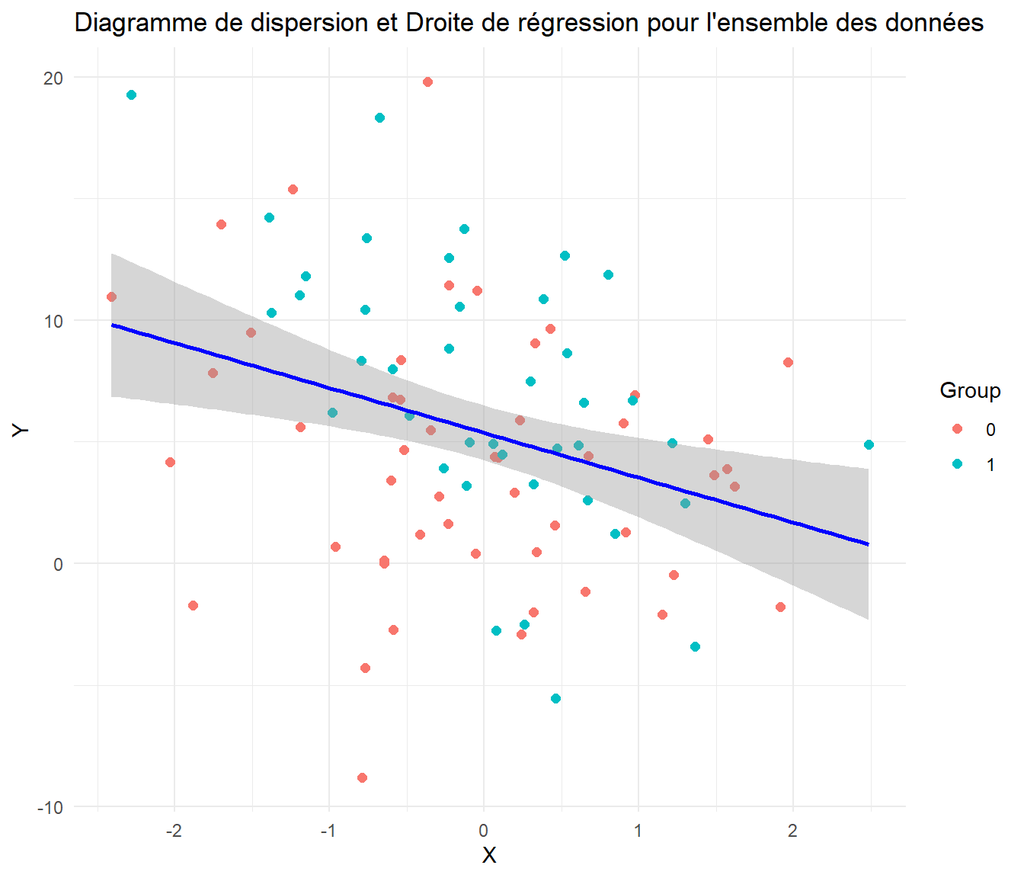

Figure 15.34: Diagramme de dispersion résumant la relation entre deux variables, pour deux groupes de sujets identifiés par des points de différentes couleurs.

```r
set.seed(150752)
# Génération des données pour le Groupe 1
x1 <- rnorm(50)
y1 <- 5 - 1.2 * x1 + rnorm(50, 0, 5)
dat1 <- data.frame(X = x1, Y = y1, Grp = rep(0, length(x1)))

# Génération des données pour le Groupe 2
x2 <- rnorm(40)
y2 <- 8 - 3.1 * x2 + rnorm(40, 0, 5)
dat2 <- data.frame(X = x2, Y = y2, Grp = rep(1, length(x2)))

dat <- rbind(dat1, dat2)

reg1 <- lm(Y ~ X, data = dat)
res1 <- summary(reg1)

ggplot(data = dat, aes(x = X, y = Y, color = factor(Grp))) +
  geom_point(size = 2) +
  geom_smooth(method = "lm",
              formula = y ~ x,
              color = "blue",
              se = TRUE) +
  scale_color_discrete(name = "Group") +
  labs(x = "X",
       y = "Y",
       title = "Diagramme de dispersion et Droite de régression pour l'ensemble des données") +
  theme_minimal()
```

```r
bsdf <- as.data.frame(coefficients(res1))
bsdf <- rbind(bsdf, r2 = c(res1$r.squared, NA, NA, NA),
              Err.Std = c(res1$sigma, NA, NA, NA))

bsdf %>%
  kbl(digits = 3, booktabs=TRUE) %>%
  kable_styling(bootstrap_options = c("striped", "hover", "condensed"),
                full_width=FALSE) %>%
  column_spec(1, bold=TRUE, background = "#7FFFD0", border_right=TRUE) %>%
  row_spec(0, bold=TRUE, background = "#7FFFD0") %>%
      row_spec(3:4, bold=TRUE, background = "yellow")
```

Table 15.14: Paramètres de régression pour deux groupes combinés

|  | Estimate | Std. Error | t value | Pr(>\|t\|) |
| --- | --- | --- | --- | --- |
| (Intercept) | 5.374 | 0.565 | 9.512 | 0.000 |
| X | -1.845 | 0.577 | -3.196 | 0.002 |
| r2 | 0.104 |  |  |  |
| Err.Std | 5.357 |  |  |  |

Les résultats obtenus indiquent une relation significative entre la variable indépendate (X) et la variable dépendante (Y), X permettant d’expliquer 10.4 % de la variabilité de Y.

La question qui se pose maintenant est de savoir si ce modèle pourrait varier en fonction du groupe d’appartenance des sujets. On peut adopter différentes stratégies pour examiner cette question.

#### 15.8.0.1 Analyses de régression séparées, par groupe

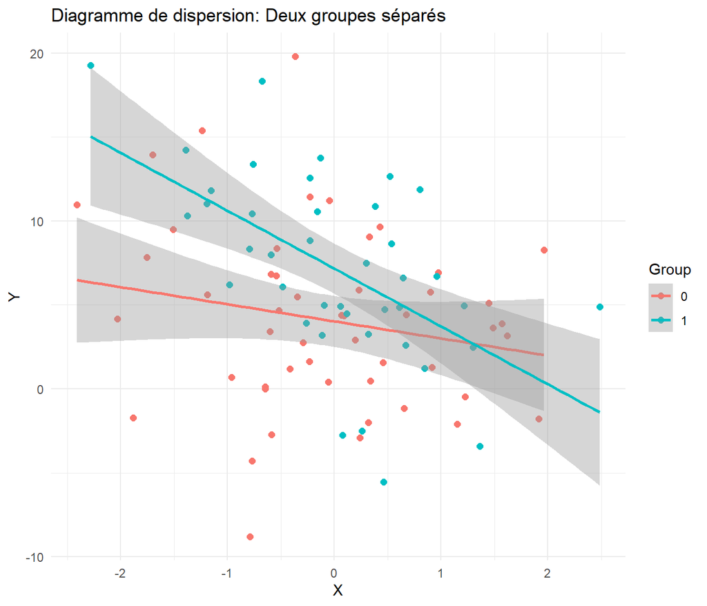

Figure 15.35: Relation entre X et Y, pour deux échantillonss.

```r
ggplot(data = dat, aes(x = X, y = Y, color = factor(Grp))) +
  geom_point(size = 2) +
  geom_smooth(method = "lm", formula = y ~ x, se = TRUE, aes(group = Grp)) +
  scale_color_discrete(name = "Group") +
  labs(x = "X", y = "Y", title = "Diagramme de dispersion: Deux groupes séparés") +
  theme_minimal()
```

De ce diagramme, on note la possibilité que la relation entre X et Y diffère d’un groupe à l’autre. En effet, l’intercept du groupe 1 pourrait être inférieur à celui du groupe 2. Il est très probable, également, que la pente de la droite de régression soit plus élevée pour le groupe 2 que pour le groupe 1. Des tests inférentiels seront nécessaires pour vérifier la signification statistique, et surtout l’importance de ces différences.

```r
reg2 <- by(dat, dat$Grp, function(z) lm(Y ~ X, data = z))

res21 <- summary(reg2[[1]])
res22 <- summary(reg2[[2]])

tbl <- rbind(c(res21$coefficients[1, 1], res22$coefficients[1, 1]),
             c(res21$coefficients[1, 2], res22$coefficients[1, 2]),
             c(res21$coefficients[1, 3], res22$coefficients[1, 3]),
             c(res21$coefficients[1, 4], res22$coefficients[1, 4]),
             c(res21$coefficients[2, 1], res22$coefficients[2, 1]),
             c(res21$coefficients[2, 2], res22$coefficients[2, 2]),
             c(res21$coefficients[2, 3], res22$coefficients[2, 3]),
             c(res21$coefficients[2, 4], res22$coefficients[2, 4]),
             c(res21$r.squared, res22$r.squared),
             c(res21$sigma, res22$sigma))
rownames(tbl) <- c("Intercept", "Err.Std (b0)", "t (b0)", "p(>|t|)",
                   "X", "Err.Std (b1)", "t (b1)", "p(>|t|)",
                   "R2", "Err.Std.Est")
colnames(tbl) <-  c("Groupe 1", "Groupe 2")
tbl %>%
  kbl(digits = 3, booktabs=TRUE) %>%
  kable_styling(bootstrap_options = c("striped", "hover", "condensed"),
                full_width=FALSE) %>%
  column_spec(1, bold=TRUE, background = "#7FFFD0", border_right=TRUE) %>%
  row_spec(0, bold=TRUE, background = "#7FFFD0") %>%
  row_spec(1:4, bold=TRUE, background = "yellow") %>%
  row_spec(5:8, bold=TRUE, background = "skyblue") %>%
  row_spec(9:10, bold=TRUE, background = "lightgreen")
```

Table 15.15: Paramètres de régression obtenus pour les groupes, séparément. Les groupes sont notés 0 et 1, et occupent chacun une rangée du tableau

|  | Groupe 1 | Groupe 2 |
| --- | --- | --- |
| Intercept | 4.024 | 7.167 |
| Err.Std (b0) | 0.756 | 0.734 |
| t (b0) | 5.325 | 9.761 |
| p(>\|t\|) | 0.000 | 0.000 |
| X | -1.019 | -3.444 |
| Err.Std (b1) | 0.725 | 0.821 |
| t (b1) | -1.404 | -4.193 |
| p(>\|t\|) | 0.167 | 0.000 |
| R2 | 0.039 | 0.316 |
| Err.Std.Est | 5.329 | 4.643 |

Les différences entre les intercepts et les coefficients de régression ressortent clairement dans ce tableau, mais aucune donnée ne nous permet de déclarer l’une ou l’autre de ces différences comme étant statistiquement significative. Cependant, on note que pour le groupe 1, la variable X n’explique que 3.9% de la variabilité de Y, alors que pour le groupe 2, cette proportion atteint 31.6%. Le coefficient de régression n’est pas significativement différent de 0 pour le premier groupe [$p(t_{48}= -1.404)>0.05$], alors que la signification de ce coefficient est confirmée pour le groupe 2 [$p(t_{38}= -4.193)<0.001$]. Dès lors, on peut douter de l’équivalence inter-groupe du modèle.

#### 15.8.0.2 Comparaison des corrélations

À la section Section 15.1.5, nous avons décrit un test de signification d’une différence de corrélations. Étant donné la relation directe entre une corrélation et un coefficient de régression, on peut appliquer ce test et vérifier la signification statistique de la différence observée entre les coefficients de régression ($b_1$) des deux groupes. Utilisant la fonction **cocor::cocor.indep.groups()**, on trouve:

```r
cocor::cocor.indep.groups(cor(subset(dat, Grp == 0)[, 1:2])[1, 2],
                          cor(subset(dat, Grp == 1)[, 1:2])[1, 2],
                          sum(dat$Grp == 0),
                          sum(dat$Grp == 1))
```

```
#>
#>   Results of a comparison of two correlations based on independent groups
#>
#> Comparison between r1.jk = -0.1986 and r2.hm = -0.5625
#> Difference: r1.jk - r2.hm = 0.3638
#> Group sizes: n1 = 50, n2 = 40
#> Null hypothesis: r1.jk is equal to r2.hm
#> Alternative hypothesis: r1.jk is not equal to r2.hm (two-sided)
#> Alpha: 0.05
#>
#> fisher1925: Fisher's z (1925)
#>   z = 1.9798, p-value = 0.0477
#>   Null hypothesis rejected
#>
#> zou2007: Zou's (2007) confidence interval
#>   95% confidence interval for r1.jk - r2.hm: 0.0021 0.6999
#>   Null hypothesis rejected (Interval does not include 0)
```

Sans surprise, on confirme la signification statistique de la différence entre les corrélations, et par conséquent, des coefficients de régressions observés. La variable X n’affecte pas la variable Y de la même manière, d’un groupe à l’autre.

#### 15.8.0.3 Le test de Chow

De la figure Figure 15.35, on note des droites de régression qui ne sont pas parallèles, indiquant une possibilité de coefficients de régression distincts pour les deux groupes. Il semble également que les intercepts soient différents.

Afin de vérifier la signification statistique des différences observées, définissons les hypothèses suivantes:

- Étant donné deux équations de régression, $\hat y=b_{01}+b_{11}X$, et $\hat y=b_{02}+b_{12}X$,
  $$H_0:\beta_{01}=\beta_{02}~~et~~\beta_{11}=\beta_{12}$$
  $$H_1:\beta_{01} \ne \beta_{02}~~et/ou~~\beta_{11} \ne\beta_{12}$$

Le test de Chow permet d’effectuer ce test de signification de la manière suivante, suivant l’équation Équation 15.42):

$$\begin{align}
F_{Chow} & =\frac{\frac{1}{p} \left [{SC_{res.tot}-\left( SC_{res.1}+SC_{res.2} \right)}\right ]}{\frac{1}{n_1+n_2-2p}(SC_{res.1}+SC_{res.2})} \\
dl_1 & =p \\
dl_2 &= n_1+n_2-2p
\end{align} \tag{15.42}$$

où

$$SC_{res.tot}=\sum\limits_{i=1}^{n_1+n_2}{(y_i-\hat y_i)^2}$$
$$SC_{res.1},~~SC_{res.2} =\sum\limits_{i=1}^{n_1,n_2}{(y_i-\hat y_i)^2}$$
$n_1,~~n_2$: nombre d’observations dans chacun des groupes
$p$: nombre de paramètres, soit 2 dans le cas d’une régression simple.

Un rejet de $H_0$ suggère que l’un ou l’autre des paramètres, ou les deux, sont significativement différents d’un groupe à l’autre.

La fonction **chow.test()**, de la librairie **gap** permet de test, sous R. Les arguments de cette fonction sont les variables Y et X de chacun des groupes:

```r
 gap::chow.test(dat1$Y, dat1$X, dat2$Y, dat2$X)
```

```
#>      F value        d.f.1        d.f.2      P value
#>  6.755885846  2.000000000 86.000000000  0.001882919
```

Pour les données analysées, on obtient un rapport F dont la probabilité d’occurrence, supposant $H_0$ vraie, est inférieur au seuil de signification $\alpha=0.05$. Les droites de régression pour les deux groupes sont donc en toute probabilité, distinctes. Ce test est cependant global, et ne nous permet pas de savoir lequel des paramètres diffère.

#### 15.8.0.4 Terme multiplicatif

La stratégie présentée dans cette section fait appel à des notions qui seront présentées ultérieurement, mais on pourra en saisir l’essentiel dès maintenant. S’il existe une différence entre les groupes, on pourra en tirer profit en incluant la variable Grp (groupe) au modèle de régression, ce qui équivaut à l’utilisation d’une variable dichotomique comme ce fut le cas à la section Section 15.3. De plus, on ajoutera une troisième variable formé par le produit de la variable indépendante (X) et la variable de groupement (Grp). Cette dernière variable sera codifiée de manière à ce que ‘0’ corresponde au groupe 1, et ‘1’ corresponde au groupe 2. Le résultat permettra de combler le vide laissé par le test de Chow en indiquant les différences tant au niveau de l’intercept qu’au niveau du coefficient de régression.

Le modèle proposé devient alors:

$$\widehat{Y}=\beta_0+\beta_1 X + \beta_2 Grp + \beta_3 X.Grp + \epsilon$$
Ce type de modèle sera discuté dans les chapitres ultérieurs. Mais pour les besoin de la discussion, notons que pour les observations du groupe 1, notées ‘0’, le terme impliquant $\beta_2$ devient nul. Pour les observations du groupe 2, $\beta_2$ augmente la valeur de $\beta_0$, et celle de $\beta_1$. $\beta_2$ devient donc une différence d’intercept et de pente: si sa valeur est nulle, les deux groupes partagent la même équation de régression.

Sous R, on procédera de la manière suivante:

```r
reg6 <- lm(Y ~ X + X*Grp, data = dat)
res6 <- summary(reg6)

coefficients(res6) %>%
  kbl(digits = 3, booktabs=TRUE) %>%
  kable_styling(bootstrap_options = c("striped", "hover", "condensed"),
                full_width=FALSE) %>%
  column_spec(1, bold=TRUE, background = "#7FFFD0", border_right=TRUE) %>%
  row_spec(0, bold=TRUE, background = "#7FFFD0") %>%
  row_spec(4, bold=TRUE, background = "yellow")
```

|  | Estimate | Std. Error | t value | Pr(>\|t\|) |
| --- | --- | --- | --- | --- |
| (Intercept) | 4.024 | 0.714 | 5.634 | 0.000 |
| X | -1.019 | 0.686 | -1.485 | 0.141 |
| Grp | 3.143 | 1.070 | 2.938 | 0.004 |
| X:Grp | -2.426 | 1.124 | -2.157 | 0.034 |

Les résultats de cette analyse reproduisent ceux observés précédemment pour les intercepts et les coefficients de X. On ajoute deux éléments essentiels: un coefficient de régression lié à la variable Grp, réflétant la différence entre les moyennes de Y entre les groupes, maintenant X constant. Cette différence s’avère significativement différente de 0. D’autre part, on obtient un coefficient lié au produit de X et de Grp, dont la valeur est également différente de 0. Cette quantité n’est autre que la différence des coefficients de régression liés à X obtenus lors d’analyses séparées des deux groupes. En conséquence, le test de signification de ce coefficient est aussi un test de signification de la différence entre les deux pentes.

De manière alternative, on pourra utiliser la fonction **anova()** pour obtenir les mêmes résultats:

```r
reg6b <- lm(Y ~ X*Grp, data=dat)
summary(reg6b)
```

```
#>
#> Call:
#> lm(formula = Y ~ X * Grp, data = dat)
#>
#> Residuals:
#>      Min       1Q   Median       3Q      Max
#> -13.6205  -3.1702   0.2453   2.8356  15.3919
#>
#> Coefficients:
#>             Estimate Std. Error t value Pr(>|t|)
#> (Intercept)   4.0238     0.7142   5.634 2.19e-07 ***
#> X            -1.0186     0.6858  -1.485  0.14111
#> Grp           3.1435     1.0700   2.938  0.00424 **
#> X:Grp        -2.4256     1.1244  -2.157  0.03378 *
#> ---
#> Signif. codes:  0 '***' 0.001 '**' 0.01 '*' 0.05 '.' 0.1 ' ' 1
#>
#> Residual standard error: 5.037 on 86 degrees of freedom
#> Multiple R-squared:  0.2257, Adjusted R-squared:  0.1986
#> F-statistic: 8.354 on 3 and 86 DF,  p-value: 6.163e-05
```

```r
# Test H_0: b2=0   différence d'intercept
# Test H_0: X:D2=0 différence de coefficient de régression.

anova(lm(Y ~ X,
         data=dat),
      lm(Y ~ X*Grp,
         data=dat))
```

```
#> Analysis of Variance Table
#>
#> Model 1: Y ~ X
#> Model 2: Y ~ X * Grp
#>   Res.Df    RSS Df Sum of Sq      F   Pr(>F)
#> 1     88 2525.2
#> 2     86 2182.3  2    342.88 6.7559 0.001883 **
#> ---
#> Signif. codes:  0 '***' 0.001 '**' 0.01 '*' 0.05 '.' 0.1 ' ' 1
```

## 15.9 Intervalles de confiance pour la régression

L’analyse de régression nous a permis d’obtenir les paramètres d’un modèle linéaire susceptible de représenter adéquatement l’ensemble des données. Pour chacun de ces paramètres, les inférences sont permises: on peut en établir l’intervalle de confiance, et/ou le soumettre à un test d’hypothèse (voir les sections Section 15.7.7 et Section 15.7.8).

À ces procédures, on peut ajouter la définition de **bandes de confiance** pour l’ensemble des valeurs prédites (Y’) formant la droite de régression, et pour l’ensemble des observations. Ces bandes ont déjà été ajoutées à différents diagrammes de dispersion dans les sections précédentes (Figures Figure 15.34 et Figure 15.35). La figure Figure 15.36 illustre le concept:

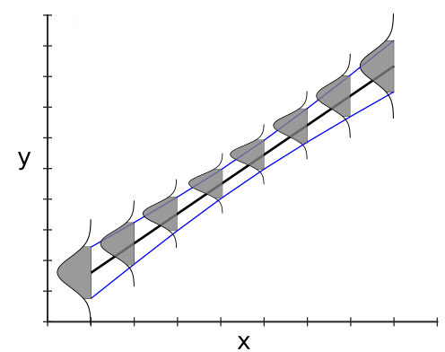

Figure 15.36: Bande de Confiance

À chacune des valeurs possibles de la variable indépendante, la distribution conditionnelle de Y est supposée normale avec une certaine dispersion (l’erreur-standard d’estimation, $\sigma_{y.x}$), et une moyenne, $\mu_{Y|X}$, égale à Y’. La bande de confiance pour les valeurs prédites rassemble tous les intervalles de confiance sur l’étendue de la variable indépendante.

La bande de confiance pour les valeurs prédites est définie par l’équation Équation 15.43:

$$\hat Y \pm t_{\alpha/2;n-2}\sqrt {CM_{Résidu} \left[\frac{1}{n}+\frac{(X-\bar X)^2}{\sum\limits_{i=1}^{n}{(X-\bar X)^2} } \right ]} \tag{15.43}$$

Et la bande de prédiction pour les observations par l’équation Équation 15.44:

$$\hat Y_i \pm t_{\alpha/2;n-2}\sqrt {CM_{Résidu} \left[1+\frac{1}{n}+\frac{(X-\bar X)^2}{\sum\limits_{i=1}^{n}{(X-\bar X)^2} } \right ]} \tag{15.44}$$

Cet intervalle capturera les observations futures avec une probabilité de $(1-\alpha)$.

#### 15.9.0.1 Exemple numérique

> Considérant les données du tableau Table 15.8, à l’intérieur de quel intervalle devrait-on trouver Y’ pour X=55, avec un niveau de confiance de 95% (1-$\alpha=0.95$)?

Pour répondre à cette question et à la suivante, on fera appel à la fonction **ConfBand()** (Listing 15.12).

```r
xp <- 55
res <- ConfBand(X, Y, 55)
cat("C[", res[[1]][1], "< Y'|X=", xp, " < ", res[[1]][2], "] = 95%")
```

```
#> C[ 99.86351 < Y'|X= 55  <  107.2703 ] = 95%
```

> Pour X = 55, à l’intérieur de quel intervalle a-t’on 95% des chances de trouver les observations futures (Y), pour (1-$\alpha)=0.95$?

```r
cat("C[", res[[2]][1], "< Yi|X=", xp, " < ", res[[2]][2], "] = 95%")
```

```
#> C[ 86.05254 < Yi|X= 55  <  121.0813 ] = 95%
```

La figure Figure 15.37 illustre la bande de confiance à 95% pour les valeurs prédites dans le cas des données sous analyse. Sa réalisation implique la fonction **RegBandPlot()** (Listing 15.13):

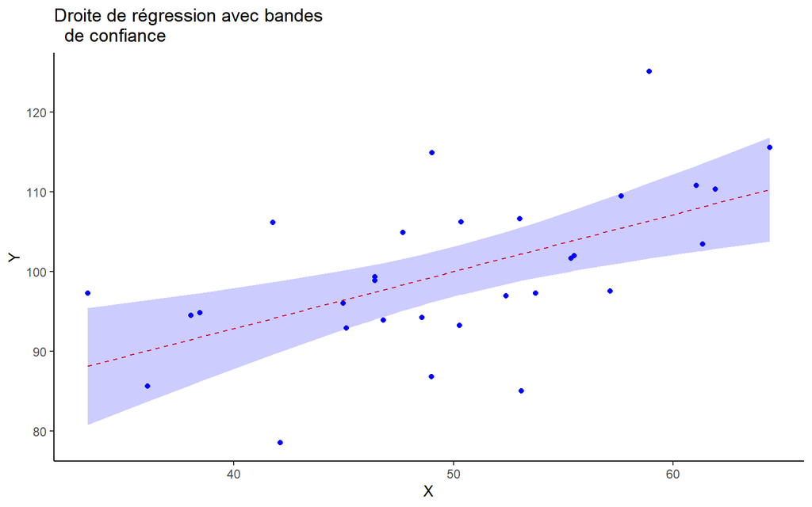

Figure 15.37: Bande de Confiance (95%).

```r
RegBandPlot(X, Y, type = "confidence")
```

De la même manière, la figure Figure 15.38 reproduit l’intervalle de prédiction, pour les mêmes données:

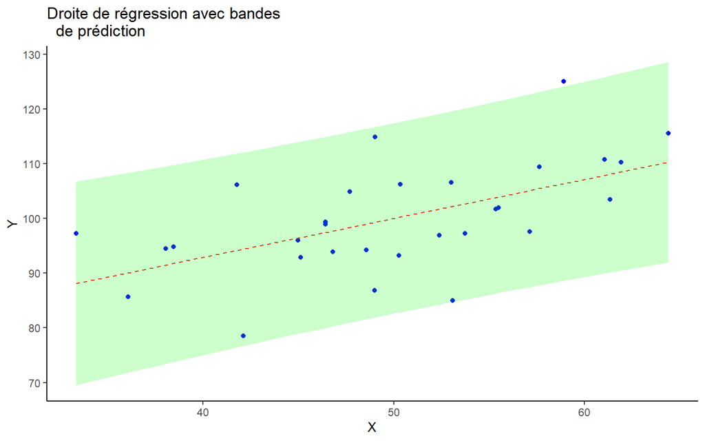

Figure 15.38: Bande de Prédiction (95%).

```r
RegBandPlot(X, Y, type = "prediction")
```

Il est souvent préférable de combiner ces deux graphiques, tel que dans la figure Figure 15.39:

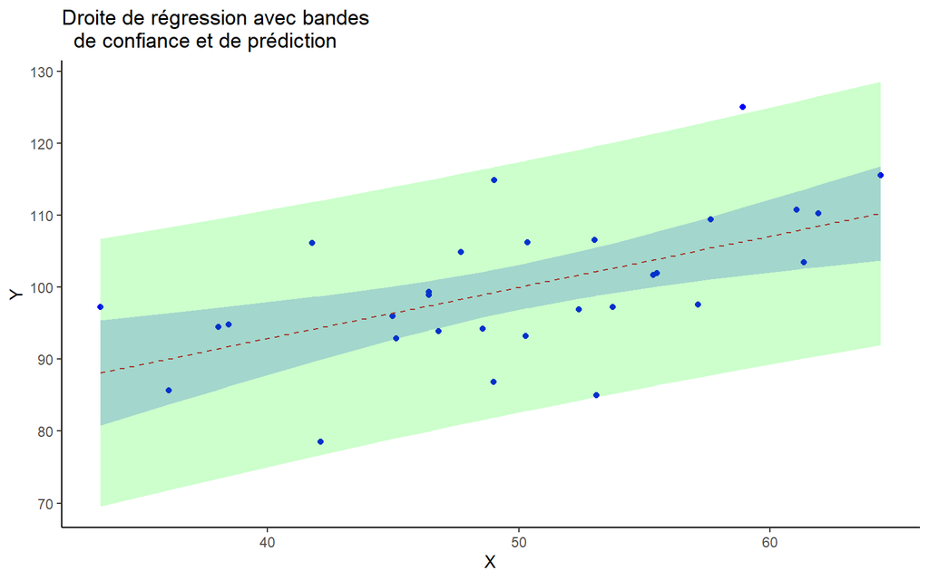

Figure 15.39: Bande de Prédiction et de Confiance (95%).

```r
RegBandPlot(X, Y, type = "both")
```

Finalement, il est souvent intéressant d’obtenir un tableau des limites inférieures et supérieures des valeurs prédites et des prédictions, avec leur représentation graphique. La fonction **RegInterval()** (Listing 15.14) pourrait être utile dans ce cas (figure Figure 15.40):

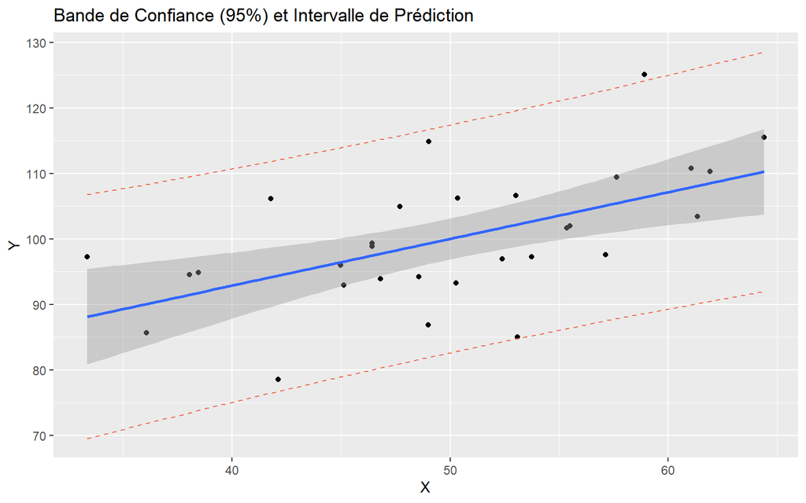

Figure 15.40: Bande de Prédiction et de Confiance (95%).

```r
resIntConf <- RegInterval(X, Y)[[1]]
```

Cette fonction permet également l’affichage des valeurs prédites et des intervalles de confiance et de prédiction correspondants (tableau Table 15.16)

```r
 resIntConf %>%
    kbl(caption = "Bande de Confiance et Intervalle de Prédiction", digits = 3) %>%
    kable_styling(bootstrap_options = c("striped", "hover", "condensed"),
                  full_width = FALSE) %>%
    column_spec(5, bold = FALSE, border_right = TRUE) %>%
    column_spec(3, bold = FALSE, border_right = TRUE) %>%
    column_spec(1, bold = TRUE, border_left = TRUE, border_right = TRUE)   #%>%
    add_header_above(c(" " = 3, "Int. Pred." = 2, "Conf. Band." = 2))
```

[output not shown]

Table 15.16: Tableau des intervalles de confiance et de prédiction (95%).

Bande de Confiance et Intervalle de Prédiction

| X | Y | Y_Pred | Pred_Inf | Pred_Sup | Conf_Inf | Conf_Sup |
| --- | --- | --- | --- | --- | --- | --- |
| 46.417 | 99.316 | 97.444 | 79.984 | 114.903 | 94.009 | 100.878 |
| 46.802 | 93.897 | 97.719 | 80.271 | 115.166 | 94.345 | 101.093 |
| 64.402 | 115.545 | 110.274 | 91.956 | 128.592 | 103.754 | 116.795 |
| 57.134 | 97.587 | 105.089 | 87.459 | 122.720 | 100.870 | 109.309 |
| 45.132 | 92.921 | 96.527 | 79.019 | 114.036 | 92.852 | 100.203 |
| 49.001 | 86.862 | 99.288 | 81.882 | 116.693 | 96.137 | 102.438 |
| 36.078 | 85.644 | 90.068 | 71.809 | 108.328 | 83.714 | 96.422 |
| 55.499 | 101.955 | 103.923 | 86.385 | 121.461 | 100.109 | 107.736 |
| 33.366 | 97.275 | 88.134 | 69.519 | 106.748 | 80.822 | 95.445 |
| 42.124 | 78.552 | 94.382 | 76.701 | 112.062 | 89.959 | 98.804 |
| 58.917 | 125.083 | 106.361 | 88.603 | 124.120 | 101.637 | 111.086 |
| 55.348 | 101.672 | 103.815 | 86.284 | 121.345 | 100.036 | 107.594 |
| 41.782 | 106.142 | 94.137 | 76.432 | 111.842 | 89.617 | 98.657 |
| 61.327 | 103.431 | 108.080 | 90.106 | 126.054 | 102.601 | 113.560 |
| 57.641 | 109.443 | 105.451 | 87.787 | 123.115 | 101.094 | 109.808 |
| 61.044 | 110.774 | 107.879 | 89.933 | 125.825 | 102.491 | 113.267 |
| 48.563 | 94.247 | 98.975 | 81.564 | 116.386 | 95.798 | 102.152 |
| 61.923 | 110.291 | 108.506 | 90.471 | 126.541 | 102.830 | 114.182 |
| 49.022 | 114.892 | 99.302 | 81.897 | 116.708 | 96.153 | 102.452 |
| 38.462 | 94.838 | 91.769 | 73.774 | 109.764 | 86.220 | 97.317 |
| 38.048 | 94.500 | 91.474 | 73.436 | 109.511 | 85.788 | 97.159 |
| 50.345 | 106.233 | 100.246 | 82.845 | 117.648 | 97.118 | 103.375 |
| 50.272 | 93.235 | 100.194 | 82.792 | 117.595 | 97.067 | 103.321 |
| 53.024 | 106.595 | 102.157 | 84.715 | 119.600 | 98.809 | 105.506 |
| 53.095 | 85.031 | 102.208 | 84.763 | 119.652 | 98.849 | 105.566 |
| 53.726 | 97.259 | 102.658 | 85.194 | 120.122 | 99.200 | 106.117 |
| 52.388 | 96.956 | 101.703 | 84.276 | 119.131 | 98.437 | 104.970 |
| 46.435 | 98.900 | 97.457 | 79.998 | 114.916 | 94.025 | 100.888 |
| 47.696 | 104.920 | 98.356 | 80.931 | 115.782 | 95.100 | 101.613 |
| 44.988 | 96.002 | 96.424 | 78.910 | 113.939 | 92.718 | 100.130 |

## 15.10 Régression Linéaire Simple: Test de Permutations

Comme pour la comparaison de deux statistiques, il est possible d’obtenir une analyse de régression à l’aide de tests de permutations. Sous R, la librairie **lmPerm** permet cette approche dans diverses situations. En particulier, la fonction **lmp()** est une modification de la fonction **lm()** de manière à utiliser les tests de permutations plutôt que la théorie normale en régression. Par exemple,

```r
  x  <-  rnorm(50)
  y  <-  0.85 * x + sqrt(1-0.85^2)*rnorm(50)

  res <- lmPerm::lmp(y~x)
```

```
#> [1] "Settings:  unique SS : numeric variables centered"
```

```r
  summary(res)
```

```
#>
#> Call:
#> lmPerm::lmp(formula = y ~ x)
#>
#> Residuals:
#>      Min       1Q   Median       3Q      Max
#> -1.33913 -0.37460  0.09426  0.40923  1.18792
#>
#> Coefficients:
#>   Estimate Iter Pr(Prob)
#> x   0.8295 5000   <2e-16 ***
#> ---
#> Signif. codes:  0 '***' 0.001 '**' 0.01 '*' 0.05 '.' 0.1 ' ' 1
#>
#> Residual standard error: 0.5504 on 48 degrees of freedom
#> Multiple R-Squared: 0.6976,  Adjusted R-squared: 0.6913
#> F-statistic: 110.7 on 1 and 48 DF,  p-value: 4.663e-14
```

En comparaison, la fonction **lm()** produit des résultats presque identiques:

```r
res <- lm(y~x)
summary(res)
```

```
#>
#> Call:
#> lm(formula = y ~ x)
#>
#> Residuals:
#>      Min       1Q   Median       3Q      Max
#> -1.33913 -0.37460  0.09426  0.40923  1.18792
#>
#> Coefficients:
#>              Estimate Std. Error t value Pr(>|t|)
#> (Intercept) 0.0006271  0.0783789   0.008    0.994
#> x           0.8295463  0.0788392  10.522 4.66e-14 ***
#> ---
#> Signif. codes:  0 '***' 0.001 '**' 0.01 '*' 0.05 '.' 0.1 ' ' 1
#>
#> Residual standard error: 0.5504 on 48 degrees of freedom
#> Multiple R-squared:  0.6976, Adjusted R-squared:  0.6913
#> F-statistic: 110.7 on 1 and 48 DF,  p-value: 4.663e-14
```

## 15.11 Le Paradoxe de Simpson

Le paradoxe de Simpson décrit une situation dans laquelle la relation observée entre deux variables varie selon la prise en compte ou non d’une autre variable, dite **confondante** (ou **facteur de confusion**). Ainsi, une relation entre X et Y peut être nulle si on ne tient pas compte d’un certain facteur, mais être forte si on contrôle ce dernier. La figure Figure 15.41 représente un exemple d’une telle situation: X et Y sont *globalement* corrélés positivement, tel que représenté par la droite de régression (en rouge), mais en considérant les 5 niveaux d’une variable confondante (sous-groupes, par exemple), la relation est inversée! La fonction **simulate_simpson()** (Listing 15.15) permet d’effectuer une telle simulation.

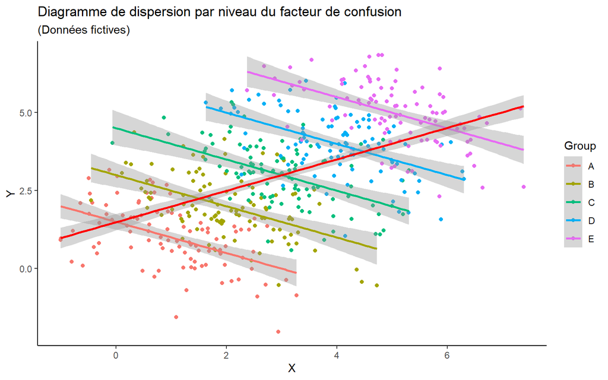

Figure 15.41: Exemple de Paradoxe de Simpson.

```r
data <- simulate_simpson(n = 100, groups = 5, r = -0.5)
ggplot(data, aes(x = V1, y = V2)) +
  geom_point(aes(color = Group)) +
  geom_smooth(aes(color = Group), method = "lm") +
  geom_smooth(method = "lm", se=TRUE, col="red") +
  labs(x = "X",
        y = "Y",
        title = "Diagramme de dispersion par niveau du facteur de confusion",
        subtitle = "(Données fictives)") +
  theme_classic()
```

Lorsqu’on connait la nature de la variable confondante, il est simple d’interpréter les résultats adéquatement. Malheureusement, il est fréquent que l’on n’en ait aucune intuition. Une connaissance approfondie du phénomène étudié est essentielle pour y parvenir.

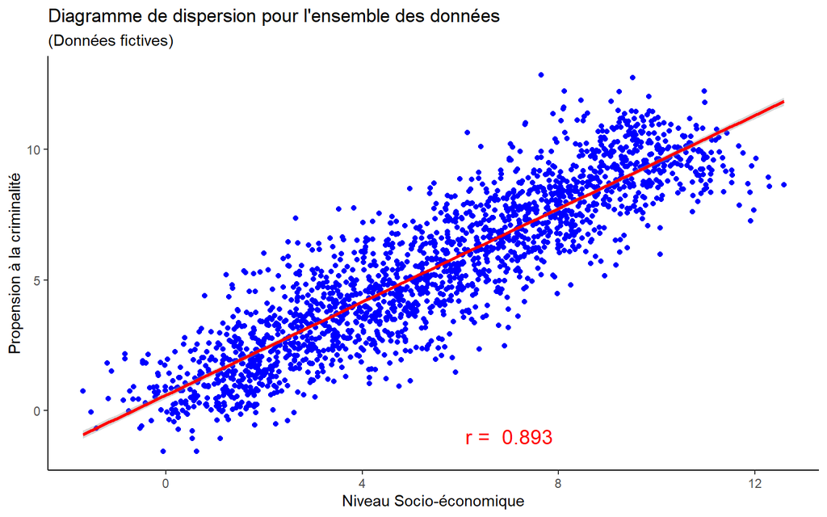

Figure 15.42: Relation positive entre les deux variables, sans tenir compte du département.

```r
data <- simulate_simpson2(n = 200, groups = 10, difference=1)
colnames(data) <- c("X", "Y", "DEPT")

ggplot(data, aes(x = X, y = Y)) +
  geom_point(color="blue") +
  geom_smooth(method = "lm", se=TRUE, col="red") +
  annotate("text", x=7, y=-1,
           label= paste("r = ", round(cor(data$X, data$Y), 3)),
           cex=5, col="red") +
  labs(x = "Niveau Socio-économique",
        y = "Propension à la criminalité",
        title = "Diagramme de dispersion pour l'ensemble des données",
        subtitle = "(Données fictives)") +
  theme_classic()
```

Il semble que l’indice de propension à la criminalité (IPC) soit positivement lié au niveau socio-économique (NSE) (r = 0.893). Ces données suggèrent que $r^2 = 79.823 \%$ de la variabilité dans le IPC s’explique par le NSE. Si l’examen des données s’arrêtait à ce point, on risquerait des conclusions erronées. En effet, imaginons que l’administration de chacun des départements utilise des moyens qui leur sont propres pour contrer la criminalité et améliorer la situation économique des résidents. Certaines mesures pourraient être plus efficaces que d’autres, ce qui fait que le département de résidence pourrait avoir un impact sur les deux variables considérées: il pourrait s’agir d’un **facteur confondant**. Reprenons l’analyse, en prenant soin d’examiner la relation entre IPC et NSE pour chacun des départements, séparément. On obtient alors la figure Figure 15.43:

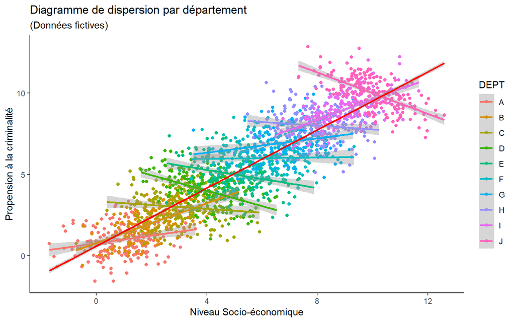

Figure 15.43: Relation variable selon le département.

```r
ggplot(data, aes(x = X, y = Y)) +
  geom_point(aes(color = DEPT)) +
  geom_smooth(aes(color = DEPT), method = "lm") +
  geom_smooth(method = "lm", se=TRUE, col="red") +
    labs(x = "Niveau Socio-économique",
        y = "Propension à la criminalité",
        title = "Diagramme de dispersion par département",
        subtitle = "(Données fictives)") +
  theme_classic()
```

En calculant la corrélation entre IPC et NSE pour chaque département, on obtient le tableau Table 15.17:

```r
data  %>%
  group_by(DEPT) %>%
  dplyr::summarize(correlation = round(cor(X, Y),4), by = "DEPT") %>%
  kbl(digits = 3) %>%
    kable_styling(bootstrap_options = c("striped", "hover", "condensed"),
                  full_width = FALSE)
```

Table 15.17: Corrélations entre IPC et NSE, par département.

| DEPT | correlation | by |
| --- | --- | --- |
| A | 0.239 | DEPT |
| B | 0.613 | DEPT |
| C | -0.117 | DEPT |
| D | -0.474 | DEPT |
| E | -0.279 | DEPT |
| F | 0.020 | DEPT |
| G | 0.220 | DEPT |
| H | -0.114 | DEPT |
| I | 0.626 | DEPT |
| J | -0.636 | DEPT |

La variation de la corrélation en fonction du département de résidence est notable: pour certains départements, la corrélation est positive, pour d’autres elle est négative, et certaines sont nulles.

Dans le monde réel, toute variable susceptible d’influencer à la fois la VI et la VD, qu’elle soit quantitative ou qualitative, peut être une source du paradoxe de Simpson. Pour être en mesure de détecter le problème, une connaissance approfondie du phénomène étudié est nécessaire.

Lorsque plusieurs variables sont disponibles dans la base de données, une analyse de regroupement (‘*Cluster Analysis*’) pourrait mettre en évidence l’existence de plusieurs sous-groupes. On peut vérifier si la relation observée pour l’ensemble tient pour chacun de ces derniers.

## 15.12 Diagnostic de la régression

Une portion importante d’une analyse de régression consiste à vérifier la validité de ses résultats, ce qui passe nécessairement par la vérification du respect des prérequis à son utilisation. Ces prérequis, ou postulats, sont:

- $\epsilon$ est une variable aléatoire avec $\mu_e=0$, et $\sigma_{\epsilon}=\sigma_{y.x}$
- La distribution de $\epsilon$ est Gaussienne
- $\sigma_{\epsilon}^2$ est la même sur toute l’étendue de la variable indépendante
- les valeurs de $\epsilon$ sont indépendantes les unes des autres

L’ingrédient essentiel de cette vérification est l’ensemble des valeurs résiduelles, qui peuvent prendre diverses formes. Pour illustrer les diverses procédures présentées dans cette section, nous utiliserons les données générées aléatoirement à l’aide du code R suivant:

```r
set.seed(150752)
x <- rnorm(50, 5, 3)
y <- 2.5 * x^2 - 5 * x - 14 + rnorm(50, 0, 24)
df <- data.frame(x, y)
```

La figure Figure 15.44 présente le diagramme de dispersion construit à partir de ces données, tout en afficant l’équation de régression linéaire et le coefficient de corrélation entre X et Y.

[figure not shown]

Figure 15.44: Diagramme de dispersion, y vs x.

```r
reg7 <- lm(y ~ x)
plot(x, y,
     main="Diagramme de dispersion, Y vs X",
     pch=19, col="blue")
abline(reg7, col="red", lwd=2)
text(min(x), max(y)-range(y)[2]/8,
     paste("Y' = ",round(reg$coefficients[1],3),
           "+",round(reg$coefficients[2],3),"X"),
     cex=1.2, pos=4)
text(min(x), max(y)-range(y)[2]/4, paste("R  = ", round(cor(x, y), 3)),
     cex=1.2, pos=4)
```

```r
equatiomatic::extract_eq(reg7,
                         use_coefs = TRUE,
                         se_subscripts = TRUE)
```

$$\operatorname{\widehat{y}} = \underset{(10.917)}{-51.32} + \underset{(1.914)}{18.84(\operatorname{x})}$$

Les statistiques inférentielles relatives à ces observations sont résumées dans les tableaux Table 15.18 et Table 15.19:

```r
res7 <- summary(reg7)
r2 <- res7$r.squared

moderndive::get_regression_table(reg7) %>%
  kable(
    digits = 3,
    caption = "Régression Linéaire",
    booktabs = TRUE,
    linesep = ""
  ) %>%
  kable_styling(bootstrap_options = c("striped", "hover", "condensed"),
                full_width=FALSE)
```

Table 15.18: Régression de X sur Y: coefficients et tests de signification .

Régression Linéaire

| term | estimate | std_error | statistic | p_value | lower_ci | upper_ci |
| --- | --- | --- | --- | --- | --- | --- |
| intercept | -51.316 | 10.917 | -4.700 | 0 | -73.267 | -29.366 |
| x | 18.843 | 1.914 | 9.843 | 0 | 14.994 | 22.692 |

```r
moderndive::get_regression_summaries(reg7) %>%
  kable(
    digits = 3,
    caption = "Qualité de l'ajustement",
    booktabs = TRUE,
    linesep = ""
  ) %>%
  kable_styling(bootstrap_options = c("striped", "hover", "condensed"),
                full_width=FALSE)
```

Table 15.19: Régression de X sur Y: Qualité d’ajustement .

Qualité de l'ajustement

| r_squared | adj_r_squared | mse | rmse | sigma | statistic | p_value | df | nobs |
| --- | --- | --- | --- | --- | --- | --- | --- | --- |
| 0.669 | 0.662 | 1708.594 | 41.335 | 42.188 | 96.881 | 0 | 1 | 50 |

Cette analyse indique que $r^2=0.669$: 66.8692712% de la variabilité de $y$ s’explique par la variable $x$. Le test de signification global indique que la probabilité d’obtenir un rapport F égal ou supérieur à $F=$ 96.881, 1, 48 est très faible ($p<0.0001$).

En bref, la relation entre les variables X et Y semble importante et le coefficient de régression a été jugé significativement différent de 0. Donc, à première vue, on sera tenté de conclure l’analyse en affirmant l’existence d’une forte relation linéaire entre X et Y. Ces résultats ne peuvent être présentés à ce stade, cependant. Il est nécessaire de s’assurer que les différents postulats à l’utilisation d’une régression linéaire dans ce cas précis sont respectés. L’analyse des valeurs résiduelles entre en jeu.

### 15.12.1 Valeurs résiduelles

Il existe plusieurs formes de valeurs résiduelles. Puisque ces quantités sont essentielles pour le diagnostic de la régression, il convient de sélectionner la forme la plus apte à détecter les problèmes susceptibles de se présenter lors d’une analyse.

- Valeurs résiduelles non-standardisées (Équation Équation 15.45):

$$e_i = Y_i-Y_i' \tag{15.45}$$

Nous connaissons déjà cette version. Le critère des moindres carrés concerne la minimisation de la somme des carrés de ces quantités. Par contre, dans un contexte de diagnostic, elles servent peu puisque leur taille dépend de l’échelle de mesure de la variable dépendante.

- Valeurs résiduelles standardisées (Équation Équation 15.46):

$$e_{z;i} =\frac{e_i}{s_{y.x}} \tag{15.46}$$

Ces valeurs expriment la distance séparant une donnée de la droite de régression en unité d’erreur-standard d’estimation. Elles sont analogues aux scores Z et s’interprètent comme tel. Le problème qui se pose ici, c’est que le numérateur et le dénominateur ne sont pas indépendants: ils concernent les mêmes quantités $(Y-Y')$ (Équation Équation 15.47):

$$e_{z;i} =\frac{Y-Y'}{\sqrt{\frac{\sum (Y-Y')^2}{n-2}}} \tag{15.47}$$

Ce fait devra être corrigé éventuellement, mais pour l’instant, nous disposons de tout ce qui est nécessaire pour évaluer certaines caractéristiques importantes de la régression:

- la linéarité de la relation
- la normalité de la distribution des résidus
- l’homocédasticité
- la présence de scores extrêmes
- l’effet de levier

#### 15.12.1.1 Diagramme de dispersion: Valeurs résiduelles vs Valeurs prédites

L’examen de diagrammes de dispersion représentant la relation entre $e_i$ (standardisé) et $Y_i$ permet de déceler plusieurs situations susceptibles de miner les résultats d’une analyse de régression. Il joue un rôle essentiel dans le diagnostic qui devrait suivre toute analyse de régression. Chacun des postulats de l’analyse y trouve son compte.

#### 15.12.1.2 La linéarité de la relation

Mention a déjà été faite que le coefficient de corrélation de Pearson est un indice de la relation **linéaire** existant entre deux variables. Puisque l’ensemble de la procédure de régression présentée ici repose sur ce coefficient, il est évident que les résultats de cette analyse ne sont valides que si la relation est effectivement linéaire. Il est donc important d’en faire la vérification.

Une première approche à l’examen de la linéarité est purement graphique. La production d’un diagramme de dispersion liant les valeurs résiduelles (erreurs) et la variable indépendante (ou les valeurs prédites $y'$, qu’elle détermine spécifiquement) est appropriée dans ce cas.

Pour les données du tableau analysées, on obtient la figure Figure 15.45 :

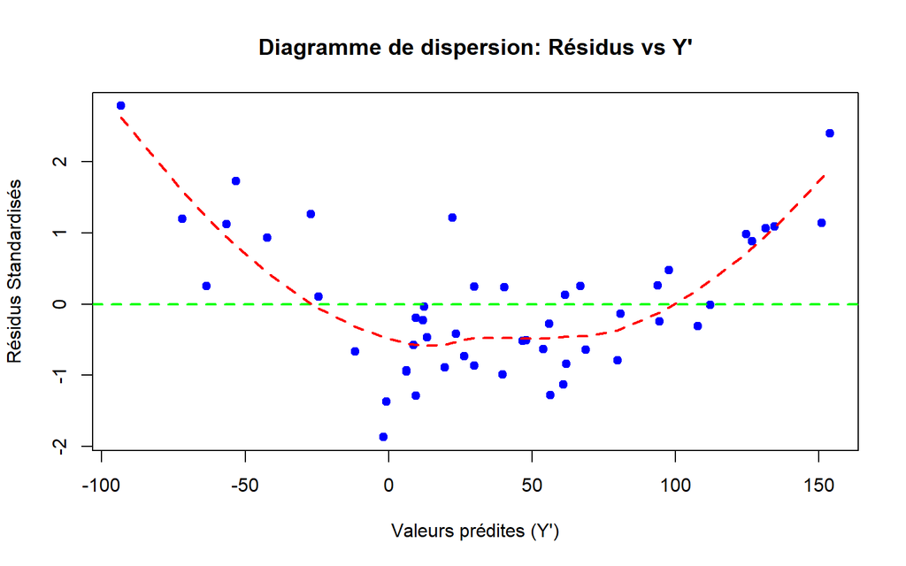

Figure 15.45: Diagramme de dispersion, Résidus vs valeurs prédites. Une courbe *loess* s’y superpose afin de mettre en évidence une éventuelle curvilinéarité.

Dans cette figure, il faut noter que les valeurs résiduelles semblent être majoritairement positives dans les deux extrémités des valeurs prédites $y'$, qui sont définies en fonction de $x$, la variable dépendante. Il semble également que dans la région centrale, une majorité de points représentent des valeurs résiduelles négatives. La ligne courbe en rouge représente la forme générale (courbe *loess*) de la relation entre les valeurs résiduelles standardisées et les valeurs de $y'$. Une courbure devient nettement apparente, indiquant que la relation pourrait dévier de la linéarité. De ce fait, cette relation est sous-estimée.

La courbure apparaissant dans la figure Figure 15.45 peut aisément être associée à une fonction du second degré (parabole). Une simple modification du modèle proposé permettrait de tenir compte de cette composante: il suffirait d’ajouter un terme quadratique au modèle, élevant au carré les valeurs de $x$, tel qu’exprimé dans l’équation Équation 15.48 :

$$\widehat{y}=\beta_0 + \beta_1 x + \beta_2 x^2 + \epsilon \tag{15.48}$$

Ce modèle prend la forme d’une fonction polynomiale du second degré. Son analyse produit les résultats suivants:

```r
xq <- x^2
regq <- lm(y ~ x + xq)
resq <- summary(regq)

moderndive::get_regression_table(regq) %>%
  kable(
    digits = 3,
    caption = "Régression Linéaire incluant un terme quadratique",
    booktabs = TRUE,
    linesep = ""
  ) %>%
  kable_styling(bootstrap_options = c("striped", "hover", "condensed"),
                full_width=FALSE)
```

Régression Linéaire incluant un terme quadratique

| term | estimate | std_error | statistic | p_value | lower_ci | upper_ci |
| --- | --- | --- | --- | --- | --- | --- |
| intercept | -17.150 | 7.635 | -2.246 | 0.029 | -32.509 | -1.790 |
| x | -6.966 | 3.070 | -2.269 | 0.028 | -13.142 | -0.790 |
| xq | 2.740 | 0.301 | 9.087 | 0.000 | 2.133 | 3.346 |

Ces résultats indiquent un impact significatif du terme quadratique ($xq = x^2$): $t_{47}=9.087, p<0.001$. La relation entre x et y n’est donc pas linéaire, mais l’ajout de $x^2$ au modèle permet de tenir compte de la composante curvilinéaire et de corriger cette situation. De plus, on trouve que maintenant, $R^2 = 0.88$, que l’on peut comparer à celui obtenu avant l’ajout du terme quadratique ($r^2 = 0.669$). Cette observation illustre le fait que toute curvilinéarité dans la relation entre deux variables produira une **sous-estimation** de cette dernière, lorsqu’analysée en supposant la linéarité.

#### 15.12.1.3 La normalité de la distribution des erreurs

La normalité de la distribution des erreurs peut se vérifier à l’aide de simples représentations graphiques, les comparant leurs formes avec celles attendues si la distribution est gaussienne, ou en ayant recours à des tests inférentiels de normalité.

##### 15.12.1.3.1 Examen graphique de la normalité

Les valeurs résiduelles forment une variable aléatoire qui en principe est distribuée normalement avec une moyenne nulle et un écart-type égal à l’erreur-standard d’estimation. On peut utiliser toute procédure permettant de valider cet énoncé (voir chapitre 5) dans ce cas. Rappelons que plusieurs représentations graphiques s’appliquent ici: histogramme, diagramme en boîte, diagramme de probabilités normales. Pour les données curvilinéaires générées pour l’exemple précédent, la figure Figure 15.46 reproduit l’histogramme, la figure Figure 15.47 le diagramme en boîte et la figure Figure 15.48 le diagramme de probabilités normales. Ces trois figures suggèrent que la distribution des valeurs résiduelle est asymétrique positive: ces valeurs ne sont pas distribuées normalement.

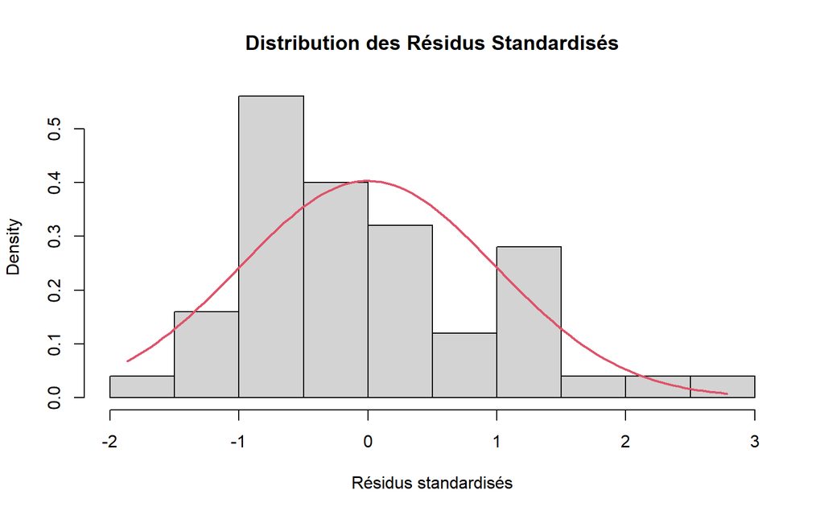

Figure 15.46: Histogramme représentant la distribution des valeurs résiduelles.

```r
hist(res.std,
     main="Distribution des Résidus Standardisés",
     xlab="Résidus standardisés",
     prob=TRUE)
xt <- seq(min(res.std), max(res.std), length=100)
ft <- dnorm(xt, mean(res.std), sd(res.std))
lines(xt, ft, col = 2, lwd = 2)
```

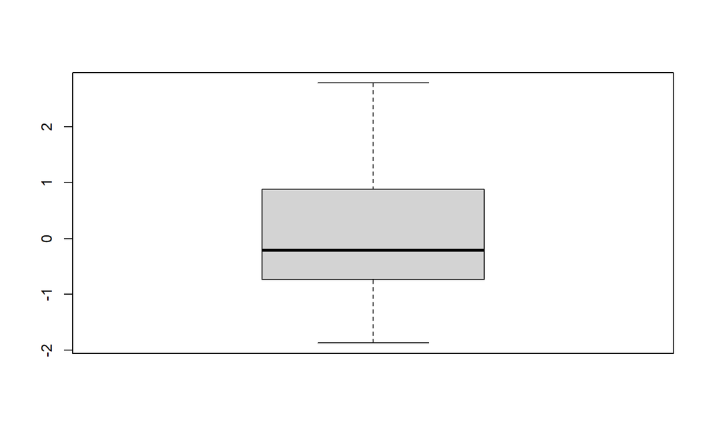

Figure 15.47: Diagramme en boîte représentant la distribution des valeurs résiduelles.

```r
boxplot(res.std)
```

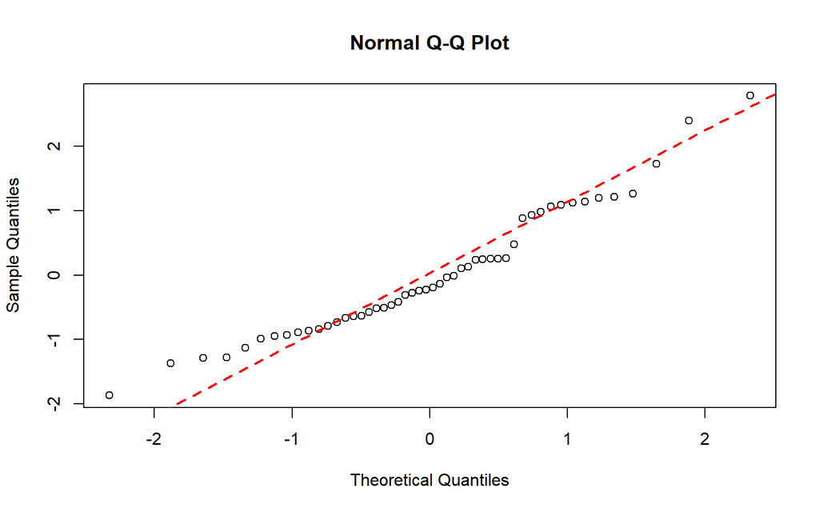

Figure 15.48: Diagramme de probabilités normales, indiquant une asymétrie positive de la distribution des erreurs.

```r
qqnorm(res.std)
qqline(res.std, col="red", lwd=2, lty=2)
```

##### 15.12.1.3.2 Tests inférentiels de normalité

Plusieurs tests de normalité existent et sont offerts par la plupart des logiciels d’analyses statistiques. Pour chacun d’eux, l’hypothèse nulle propose que la distribution étudiée (celle des erreurs en ce qui nous concerne) est normale.

Sous R, le test de Shapiro-Wilk produit le résultat suivant:

```r
res <- shapiro.test(res.std)
res
```

```
#>
#>  Shapiro-Wilk normality test
#>
#> data:  res.std
#> W = 0.95529, p-value = 0.05646
```

La probabilité d’obtenir W = 0.955 est supérieure au niveau de signification $\alpha=0.05$, ce qui nous amène à retenir $H_0$ et à conclure que la distribution des valeurs résiduelles ne se démarque pas significativement d’une distribution Gaussienne.

Notons que le test de Shapiro-Wilk est influencé par la taille de l’échantillon:

- pour de grands échantillons, de légers écarts de normalité suffisent pour que l’on rejette $H_0$
- pour de petits échantillons, le test n’est pas suffisamment sensible à la non-normalité: il est plus difficile de rejeter $H_0$.

Dans le cas présent, l’échantillon est de faible taille ($n=50$), ce qui pourrait illustrer ce point.

La librairie **nortest** offre 5 tests de normalité de ce type:

```r
nortest::ad.test(res.std)     # Anderson-Darling
```

```
#>
#>  Anderson-Darling normality test
#>
#> data:  res.std
#> A = 0.77622, p-value = 0.0409
```

```r
nortest::cvm.test(res.std)    # Cramer-von Moses
```

```
#>
#>  Cramer-von Mises normality test
#>
#> data:  res.std
#> W = 0.13154, p-value = 0.04029
```

```r
nortest::lillie.test(res.std) # Lilliefors (Kolmogorov-Smirnov)
```

```
#>
#>  Lilliefors (Kolmogorov-Smirnov) normality test
#>
#> data:  res.std
#> D = 0.11696, p-value = 0.08474
```

```r
nortest::pearson.test(res.std)# Chi-Carré de Pearson
```

```
#>
#>  Pearson chi-square normality test
#>
#> data:  res.std
#> P = 12.8, p-value = 0.07713
```

```r
nortest::sf.test(res.std)     # Shapiro-Wilk
```

```
#>
#>  Shapiro-Francia normality test
#>
#> data:  res.std
#> W = 0.95452, p-value = 0.05145
```

Pour les données analysées, les résultats de ces tests sont conflictuels, mais tous rejettent ou maintiennent de peu $H_0$.  
En effet, la probabilité (*p-value*) associée à chacun de ces tests (en supposant $H_0$ vraie) est soit légèrement inférieure ou supérieure au niveau de signification $\alpha=0.05$. Il faudra garder à l’esprit la possibilité que le postulat de normalité des erreurs pourrait avoir un impact (possiblement négligeable) sur les conclusions de l’analyse.

#### 15.12.1.4 Homoscédasticité

##### 15.12.1.4.1 Examen graphique

Un postulat essentiel de la régression linéaire est que la variabilité des erreurs est la même sur toute l’étendue de la variable indépendante. Une relation ‘hétéroscédastique’ se traduirait par une variation dans la précision des prédictions de Y à partir de X. Formellement, l’hétéroscédasticité est une condition dans laquelle la variabilité des erreurs est une fonction de la variable indépendante: $\sigma_{Résidus}^2=\gamma_0+\gamma_1 X$.

Le diagramme de dispersion des résidus vs les valeurs prédites (ou simplement $x$) permet de déceler ce type de situation. Par exemple, considérons les données suivantes:

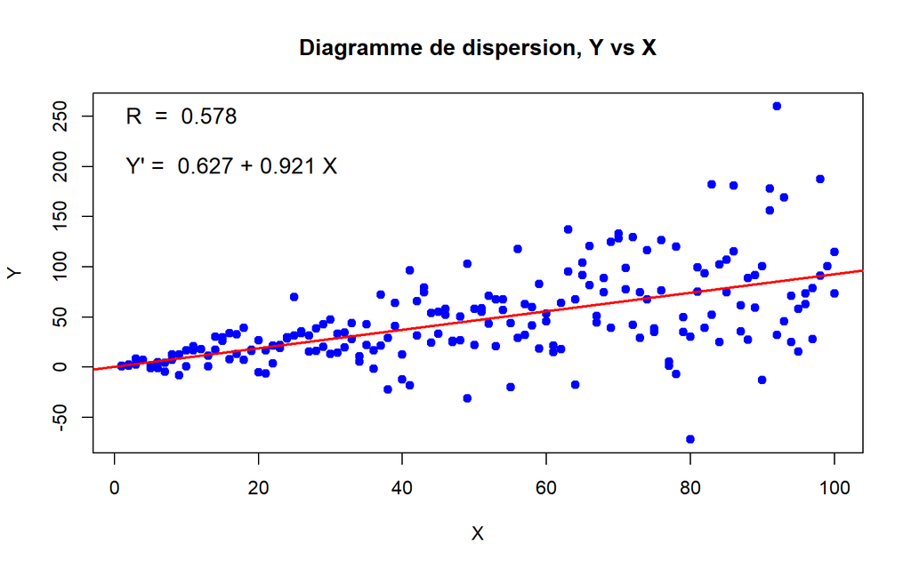

Figure 15.49: Relation présentant une forme d’hétéroscédasticité: Les erreurs dépendent de la variable indépendante, dans une certaine mesure.

```r
moderndive::get_regression_table(reg8) %>%
  kable(
    digits = 3,
    caption = "Illustration d'erreurs fonction de la variable indépendante: Hétéroscédasticité",
    booktabs = TRUE,
    linesep = ""
  ) %>%
  kable_styling(bootstrap_options = c("striped", "hover", "condensed"),
                full_width=FALSE)
```

Table 15.20: Régression de X sur Y: La variabilité des erreurs dépend de la valeur de la variable indépendante .

Illustration d'erreurs fonction de la variable indépendante: Hétéroscédasticité

| term | estimate | std_error | statistic | p_value | lower_ci | upper_ci |
| --- | --- | --- | --- | --- | --- | --- |
| intercept | 0.627 | 5.379 | 0.116 | 0.907 | -9.981 | 11.234 |
| xh | 0.921 | 0.092 | 9.960 | 0.000 | 0.739 | 1.103 |

```r
moderndive::get_regression_summaries(reg8) %>%
  kable(
    digits = 3,
    caption = "Qualité de l'ajustement",
    booktabs = TRUE,
    linesep = ""
  ) %>%
  kable_styling(bootstrap_options = c("striped", "hover", "condensed"),
                full_width=FALSE)
```

Table 15.21: Régression de X sur Y: Qualité d’ajustement .

Qualité de l'ajustement

| r_squared | adj_r_squared | mse | rmse | sigma | statistic | p_value | df | nobs |
| --- | --- | --- | --- | --- | --- | --- | --- | --- |
| 0.334 | 0.33 | 1410.832 | 37.561 | 37.75 | 99.192 | 0 | 1 | 200 |

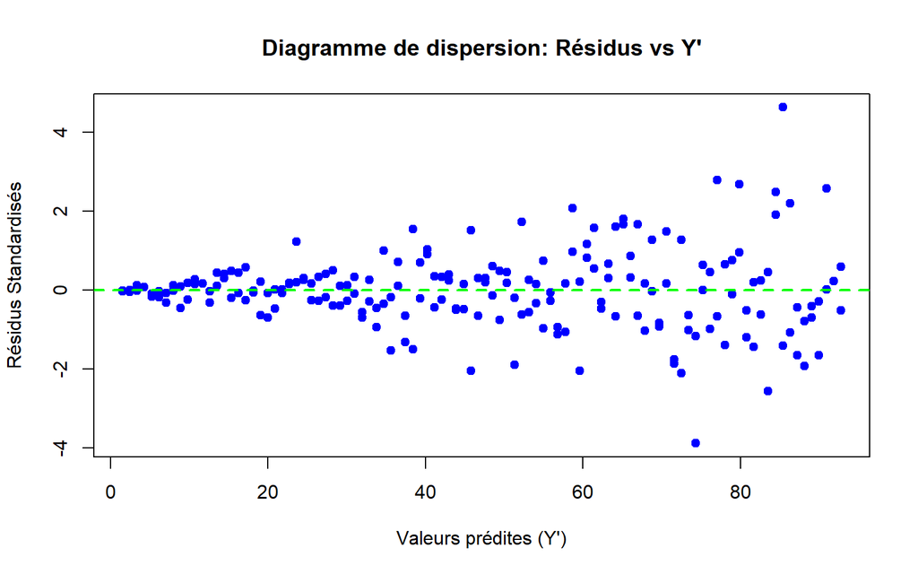

```r
res.stdh <- reg8$residuals / summary(reg8)$sigma


plot(reg8$fitted.values, res.stdh,
     main="Diagramme de dispersion: Résidus vs Y'",
     xlab="Valeurs prédites (Y')",
     ylab="Résidus Standardisés",
     pch=19, col="blue")
abline(h=0, lty=2, lwd=2, col="green")
```

L’examen graphique indique clairement qu’il y a hétéroscédasticité: une augmentation de X se traduit non seulement par une augmentation de Y, mais aussi de la variabilité de cette variable.

##### 15.12.1.4.2 Tests inférentiels

Le test de Breush_Pagan et le test NCV (*Non-Constant Variance*) permettent la vérification de l’homoscédasticité pour un ensemble de données. $H_0$ propose que la variabilité des résidus est la même sur toute l’étendue de la variable indépendante.

Sous R, la fonction **bptest()** de la librairie **lmtest**, et la fonction **ncvTest()** de la librairie **car** effectuent les calculs nécessaires:

```r
lmtest::bptest(reg8)
```

```
#>
#>  studentized Breusch-Pagan test
#>
#> data:  reg8
#> BP = 26.929, df = 1, p-value = 2.111e-07
```

```r
car::ncvTest(reg8)
```

```
#> Non-constant Variance Score Test
#> Variance formula: ~fitted.values
#> Chisquare = 70.24259, Df = 1, p = < 2.22e-16
```

Les deux fonctions indiquent clairement la présence d’hétéroscédasticité: les probabilités d’observer leurs statistiques respectives, en supposant une relation homoscédastique, sont très faibles, ce qui conduit au rejet de l’hypothèse d’homoscédasticité.

Le test de Breush-Pagan suppose que s’il y a hétéroscédasticité, la relation entre $\sigma_{Résidus}^2$ et $X$ est linéaire. Le test de White ouvre la porte à la possibilité d’une relation curvilinéaire. La fonction **white()** de la librairie **skedastic** effectue ce test:

```r
skedastic::white(reg8)
```

```
#> # A tibble: 1 × 5
#>   statistic     p.value parameter method       alternative
#>       <dbl>       <dbl>     <dbl> <chr>        <chr>
#> 1      28.0 0.000000812         2 White's Test greater
```

#### 15.12.1.5 Scores extrêmes

En régression, une valeur extrême se traduit par une valeur résiduelle très élevée. Dans un diagramme de dispersion, une telle donnée est représentée par un point éloigné de la droite de régression. Les données reproduites dans le tableau Table 15.22) permettront d’illustrer les différents concepts présentés dans cette section. La Figure 15.50 reproduit le diagramme de dispersion pour ces données.

```r
x <-c(0.10, 0.45, 0.87, 1.10, 1.28, 2.21, 2.50, 3.04, 3.24,
      4.45, 4.17, 5.28, 5.59, 5.92, 6.66, 6.80, 7.98, 3.27,
      2.58, 4.38, 8.70, 9.16, 4.26)
y <- c(0.07,  4.17,  25.95, 6.57, 13.81, 11.45, 12.96, 20.16,
       17.56, 26.03, 22.76, 26.30, 30.69, 33.94, 30.92, 34.11,
       23.36, 22.33, 18.72, 20.78, 46.55, 45.77, 40.78)
ID <- 1:23
dat <- data.frame(ID, x, y)
dat %>%
  kbl(caption="Données fictives")%>%
  kable_styling(bootstrap_options = c("striped", "hover", "condensed"),
                full_width = FALSE)
```

Table 15.22: Données fictives illustrant l’influence d’un score sur la régression

Données fictives

| ID | x | y |
| --- | --- | --- |
| 1 | 0.10 | 0.07 |
| 2 | 0.45 | 4.17 |
| 3 | 0.87 | 25.95 |
| 4 | 1.10 | 6.57 |
| 5 | 1.28 | 13.81 |
| 6 | 2.21 | 11.45 |
| 7 | 2.50 | 12.96 |
| 8 | 3.04 | 20.16 |
| 9 | 3.24 | 17.56 |
| 10 | 4.45 | 26.03 |
| 11 | 4.17 | 22.76 |
| 12 | 5.28 | 26.30 |
| 13 | 5.59 | 30.69 |
| 14 | 5.92 | 33.94 |
| 15 | 6.66 | 30.92 |
| 16 | 6.80 | 34.11 |
| 17 | 7.98 | 23.36 |
| 18 | 3.27 | 22.33 |
| 19 | 2.58 | 18.72 |
| 20 | 4.38 | 20.78 |
| 21 | 8.70 | 46.55 |
| 22 | 9.16 | 45.77 |
| 23 | 4.26 | 40.78 |

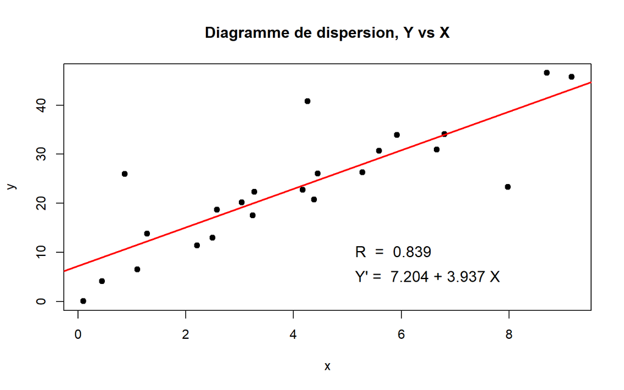

Figure 15.50: Diagramme de dispersion pour les données du tableau Table 15.22

```r
reg0 <- lm(y~x, data=dat)
plot(x, y,
     main="Diagramme de dispersion, Y vs X",
     pch= 19)
abline(reg0, col="red", lwd=2)

text(5,5,paste("Y' = ",round(reg0$coefficients[1],3),
               "+",round(reg0$coefficients[2],3),"X"),
     cex=1.2, pos=4)
text(5, 10, paste("R  = ", round(cor(x, y), 3)),
     cex=1.2, pos=4)
```

On note une relation positive forte entre X et Y. Les résultats de l’analyse de régression effectuée sur ces données sont résumés dans le tableau Table 15.23).

```r
res <- c(reg0$coefficients,
         summary(reg0)$r.squared,
         summary(reg0)$sigma,
         summary(reg0)$fstatistic)
res <- as.data.frame(res)
colnames(res) <- "Résultat"
rownames(res) <- c("b0", "b1", "R2", "Err.Std.", "F", "dl1", "dl2")
res %>%
  kbl(caption="Statistiques de régression: Ensemble des données", digits=3) %>%
  kable_styling(bootstrap_options = c("striped", "hover", "condensed"),
                full_width=FALSE)
```

Table 15.23: Statistiques de Régression: Modèle initial

Statistiques de régression: Ensemble des données

|  | Résultat |
| --- | --- |
| b0 | 7.204 |
| b1 | 3.937 |
| R2 | 0.705 |
| Err.Std. | 6.825 |
| F | 50.084 |
| dl1 | 1.000 |
| dl2 | 21.000 |

Le coefficient de régression $b_1=3.94$ est significativement différent de zéro, ce qui indique que la variable indépendante contient des informations permettant la prédiction de la variable dépendante. De fait, la variable X permet d’expliquer environ 70% ($R^2=0.70$) de la variabilité de la variable Y.

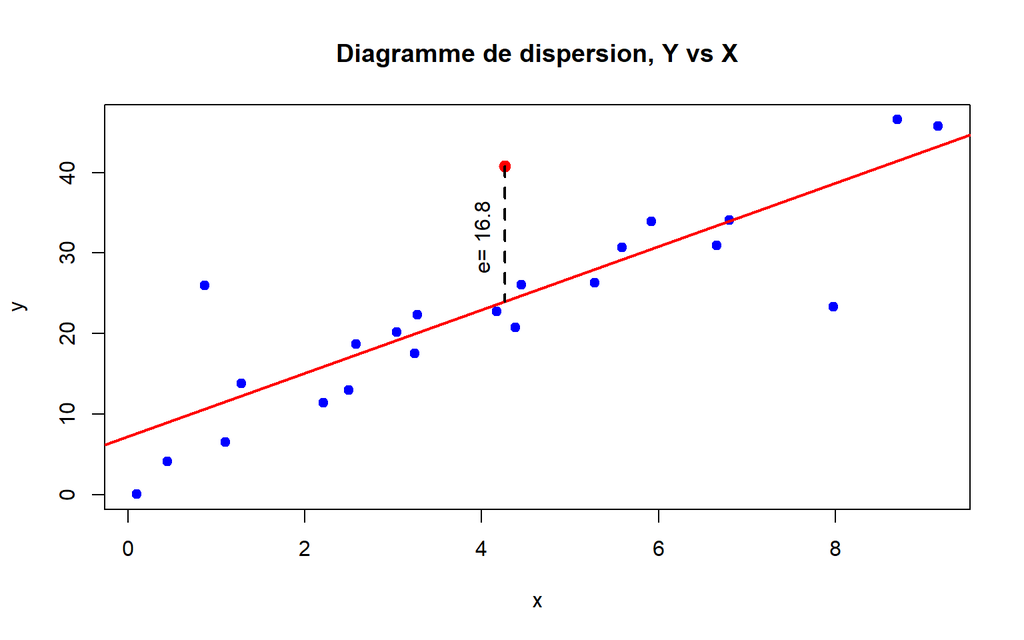

Figure 15.51: Valeur résiduelle élevée, autour de la moyenne de X

```r
plot(x, y,
     main="Diagramme de dispersion, Y vs X",
     pch= 19, col=ifelse(x==4.26, "red","blue"), cex=ifelse(x==4.26, 1.2, 1))
abline(reg0, col="red", lwd=2)
xt <- predict(reg0, data.frame(x=c(4.26)))
segments(4.26, 40.78, 4.26, xt, lty=2, lwd=2)
text(4, 32, paste("e=", round(residuals(reg0)[which(x==4.26)],2)), cex=1, srt=90)
```

La question qui nous vient à l’esprit à ce stade est: **est-ce que ce point affecte les résultats de l’analyse?** On sait en effet qu’une donnée extrême risque d’avoir un impact important sur la moyenne d’un ensemble de données. Puisque la droite de régression est l’équivalent bivarié de la moyenne, on pourrait imaginer une réponse positive à la question posée. Examinons les résultats que l’on obtient en ré-analysant les données en omettant la donnée extrême identifiée, résumés dans le tableau Table 15.24). Les résultats de l’analyse effectuée sur l’ensemble des données apparaissent sous *Inclus*, et ceux obtenus en omettant le point extrême sous *Exclus*. La figure Figure 15.52 représente cette situation graphiquement.

> Note: Pour les besoins de la démonstration, les points $ID_3$ et $ID_{21}$ ont été retirés de l’analyse.

```r
dat1 <- dat[-c(3, 21), ]
dat2 <- dat[-c(3, 21, 23), ]

reg1 <- lm(y~x, data=dat1)
reg2 <- lm(y~x, data=dat2)
res <- data.frame(c(reg1$coefficients,
                    summary(reg1)$r.squared,
                    summary(reg1)$sigma,
                    summary(reg1)$fstatistic),
                  c(reg2$coefficients,
                    summary(reg2)$r.squared,
                    summary(reg2)$sigma,
                    summary(reg2)$fstatistic))
colnames(res) <- c("Inclus", "Exclus")
rownames(res) <- c("b0", "b1", "R2", "Err.Std.", "F", "dl1", "dl2")
res %>%
  kbl(caption="Impact d'une valeur résiduelle extrême", digits=3) %>%
  kable_styling(bootstrap_options = c("striped", "hover", "condensed"),
                full_width=FALSE) %>%
  row_spec(2, bold=TRUE, background="#7FFFD0") %>%
  add_header_above(c(" "=1, "Résidu Extrême"=2))
```

Impact d'une valeur résiduelle extrême

|  | Résidu Extrême Inclus | Résidu Extrême Exclus |
| --- | --- | --- |
| b0 | 5.405 | 4.670 |
| b1 | 4.143 | 4.105 |
| R2 | 0.746 | 0.847 |
| Err.Std. | 6.038 | 4.489 |
| F | 55.918 | 99.317 |
| dl1 | 1.000 | 1.000 |
| dl2 | 19.000 | 18.000 |

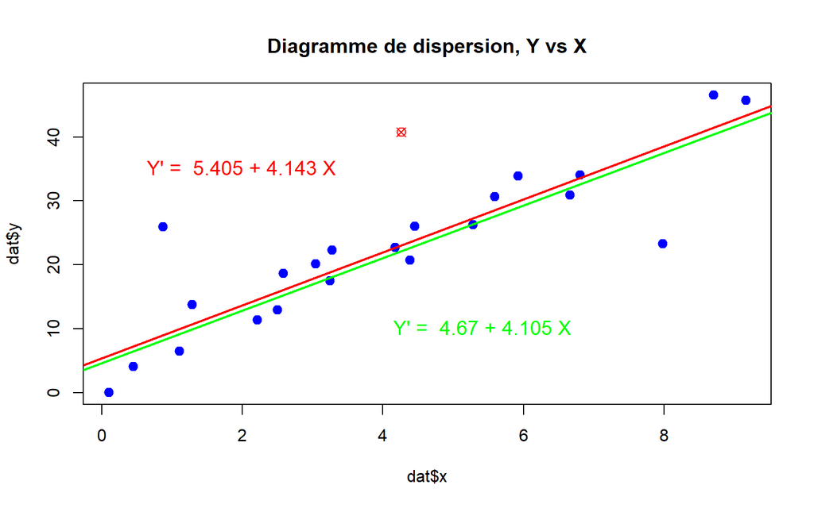

Figure 15.52: Impact d’une valeur résiduelle élevée, autour de la moyenne de X

```r
plot(dat$x, dat$y,
     pch=ifelse(dat$ID==23, 13, 19),
     col=ifelse(dat$ID==23, "red", "blue"),
     cex=1.2)
title("Diagramme de dispersion, Y vs X", line=1.5)
abline(reg2, col="green", lwd=2)
abline(reg1, col="red", lwd=2)
text(0.5,35,paste("Y' = ",round(reg1$coefficients[1],3),
                "+",round(reg1$coefficients[2],3),"X"),
     cex=1.2, pos=4, col="red")
text(4,10,paste("Y' = ",round(reg2$coefficients[1],3),
               "+",round(reg2$coefficients[2],3),"X"),
     cex=1.2, pos=4, col="green")
```

L’omission de la donnée extrême n’a eu que très peu d’effet sur la régression. L’intercept et son erreur-standard ont légèrement diminué suite au retrait de la donnée extrême, mais le coefficient de régression est demeuré pratiquement inchangé. Et comme on pouvait s’y attendre, le coefficient de détermination augmente, l’erreur-standard diminue, et le rapport F augmente, puisqu’une valeur résiduelle extrême a été soustraite de l’ensemble. Il semble donc qu’une donnée située près de la moyenne de la variable indépendante et associée à une valeur résiduelle importante a peu d’impact sur le coefficient de régression, qui est l’élément central du modèle.

Une valeur extrême peut également se présenter au niveau de la variable indépendante. Ce pourrait être le cas des points $ID_{21}:(8.70, 46.55)$ et $ID_{22}:(9.16, 45.77)$, identifiés en rouge dans le diagramme Figure 15.53.

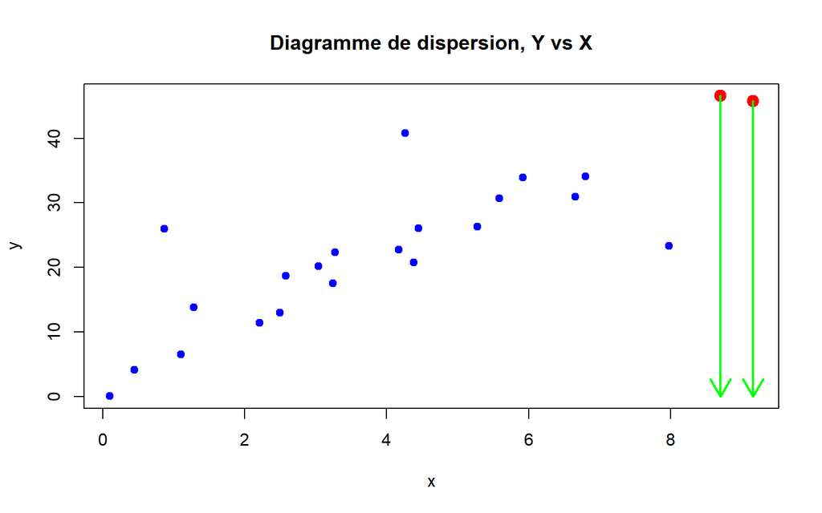

Figure 15.53: Données extrêmes sur la VI”

```r
plot(x, y,
     main="Diagramme de dispersion, Y vs X",
     pch= 19,
     col=ifelse(x>=8.70, "red","blue"),
     cex=ifelse(x>=8.70, 1.5, 1))
abline(reg, col="red", lwd=2)
arrows(8.70, 46.55, 8.70, 0, lwd=2, col="green", length=0.2)
arrows(9.16, 45.77, 9.16, 0, lwd=2, col="green", length=0.2)
```

Ces points sont éloignés de la moyenne de la variable indépendante (X), mais les valeurs résiduelles correspondantes sont faibles. En omettant ces deux points de l’analyse, on obtient les résultats présentés dans le tableau Table 15.25, et représentés à la figure Figure 15.54.

```r
dat1 <- dat[-c(3,17,23), ]
reg1 <- lm(y~x, data=dat1)
dat2 <- dat1[-which(dat2$x>=8.70), ]
reg2 <- lm(y~x, data=dat2)

res <- data.frame(c(reg1$coefficients,
                    summary(reg1)$r.squared,
                    summary(reg1)$sigma,
                    summary(reg1)$fstatistic),
                  c(reg2$coefficients,
                    summary(reg2)$r.squared,
                    summary(reg2)$sigma,
                    summary(reg2)$fstatistic))
colnames(res) <- c("Inclus", "Exclus")
rownames(res) <- c("b0", "b1", "R2", "Err.Std.", "F", "dl1", "dl2")
res %>%
  kbl(caption="Impact d'une valeur résiduelle extrême", digits=3) %>%
  kable_styling(bootstrap_options = c("striped", "hover", "condensed"),
                full_width=FALSE) %>%
  row_spec(2, bold=TRUE, background="#7FFFD0") %>%
  add_header_above(c(" "=1, "Résidu Extrême"=2))
```

Table 15.25: Régression de X sur Y, omettant deux valeurs extrêmes sur X

Impact d'une valeur résiduelle extrême

|  | Résidu Extrême Inclus | Résidu Extrême Exclus |
| --- | --- | --- |
| b0 | 2.960 | 2.810 |
| b1 | 4.778 | 4.831 |
| R2 | 0.958 | 0.948 |
| Err.Std. | 2.642 | 2.706 |
| F | 408.561 | 310.537 |
| dl1 | 1.000 | 1.000 |
| dl2 | 18.000 | 17.000 |

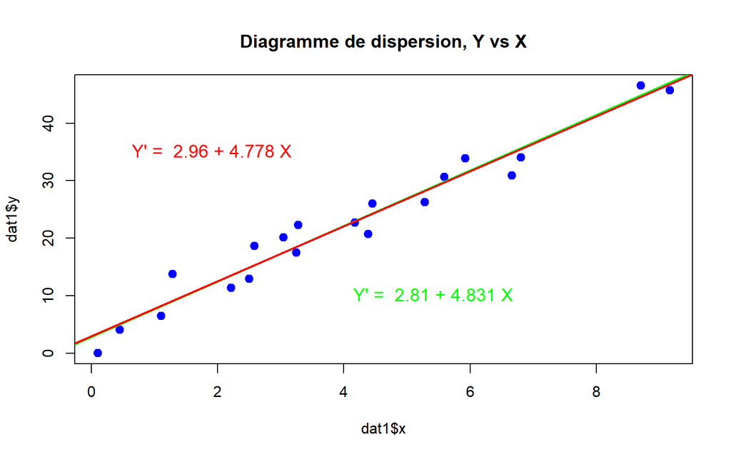

```r
plot(dat1$x, dat1$y,
     pch=ifelse(dat1$ID==23, 13, 19),
     col=ifelse(dat1$ID==23, "red", "blue"),
     cex=1.2)
title("Diagramme de dispersion, Y vs X", line=1.5)
abline(reg2, col="green", lwd=2)
abline(reg1, col="red", lwd=2)
text(0.5,35,paste("Y' = ",round(reg1$coefficients[1],3),
                "+",round(reg1$coefficients[2],3),"X"),
     cex=1.2, pos=4, col="red")
text(4,10,paste("Y' = ",round(reg2$coefficients[1],3),
               "+",round(reg2$coefficients[2],3),"X"),
     cex=1.2, pos=4, col="green")
```

On note que l’omission des deux données extrêmes sur la variable indépendante n’affecte que très peu les résultats de l’analyse. Le coefficient de détermination et le rapport F ont légèrement diminué, du fait que des données renforçant la relation ont été omises. Mais dans l’ensemble, aucun changement significatif n’est apparent. Conceptuellement, cela fait du sens puisque les valeurs résiduelles correspondant aux données omises étaient faibles; il pourrait en être autrement, si ces valeurs étaient élevées. En effet, un point occupant une position *extrême* sur l’axe horizontal confère à ce point un pouvoir important: il peut exercer un effet de levier que l’on pourra quantifier. Pour illustrer cet effet, considérons l’impact qu’une valeur résiduelle importante associée à un point localisé à l’une ou l’autre des extrémités de la variable indépendante peut avoir sur le coefficient de régression.

#### 15.12.1.6 Effet de levier

Dans le paragraphe précédent, on aura compris que la position d’un point sur l’axe de la variable indépendante est déterminante sur l’impact qu’une valeur résiduelle extrême peut avoir sur le coefficient de régression. Pour visualiser cet impact, examinons les variations dans le coefficient de régression, suite à l’omission des observations $ID_3$ et $ID_{17}$ de l’analyse, tel qu’illustré par la figure Figure 15.55 :

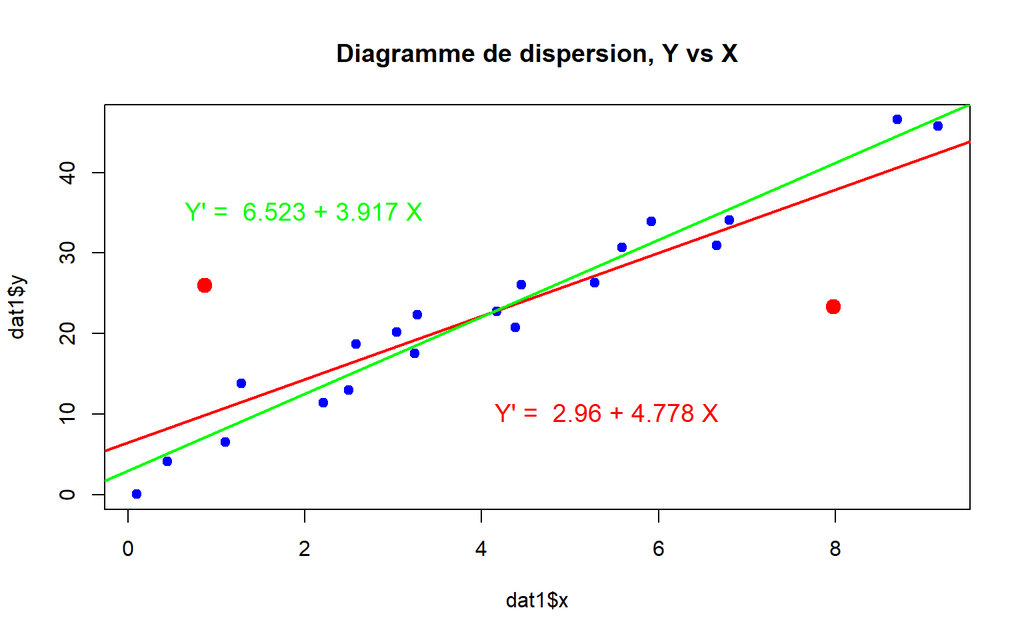

À un niveau plus formel, examinons les différences pour les statistiques relatives aux deux régressions. Le tableau Table 15.26) résume ces résultats:

```r
res <- data.frame(c(reg1$coefficients,
                    summary(reg1)$r.squared,
                    summary(reg1)$sigma,
                    summary(reg1)$fstatistic),
                  c(reg2$coefficients,
                    summary(reg2)$r.squared,
                    summary(reg2)$sigma,
                    summary(reg2)$fstatistic))
colnames(res) <- c("Inclus", "Exclus")
rownames(res) <- c("b0", "b1", "R2", "Err.Std.", "F", "dl1", "dl2")
res %>%
  kbl(caption="Impact d'une valeur résiduelle extrême", digits=3) %>%
  kable_styling(bootstrap_options = c("striped", "hover", "condensed"),
                full_width=FALSE) %>%
  row_spec(2, bold=TRUE, background="#7FFFD0") %>%
  add_header_above(c(" "=1, "Résidu Extrême"=2))
```

Table 15.26: Effet de levier élevé

Impact d'une valeur résiduelle extrême

|  | Résidu Extrême Inclus | Résidu Extrême Exclus |
| --- | --- | --- |
| b0 | 6.523 | 2.960 |
| b1 | 3.917 | 4.778 |
| R2 | 0.772 | 0.958 |
| Err.Std. | 5.844 | 2.642 |
| F | 67.604 | 408.561 |
| dl1 | 1.000 | 1.000 |
| dl2 | 20.000 | 18.000 |

De ce tableau, on note que suite au retrait des deux données extrêmes:

- la valeur de l’intercept a diminué: les données extrêmes attiraient la droite de régression vers elles. On se souviendra que c’est exactement ce que fait un score extrême dans une distribution univariée: il attire vers lui la moyenne.
- la pente a aussi augmenté.
- le coefficient de détermination augmenté de manière importante, ce qui est prévisible: plus la $SC_{Résidu}$ diminue, plus $SC_{Régression}$ augmente, et par conséquent $R^2$ augmente.
- le rapport F augmente de manière importante, en raison de la diminution de la variance d’erreur produite par l’élimination des scores extrêmes.

En bref, tous les indices sont affectés, y compris le coefficient de régression, l’élément essentiel de l’exercice! Les points étudiés semblent avoir une **effet de levier** important, effet qu’ils doivent uniquement à l’écart $(X-\bar X)$ et que l’équation Équation 15.49 définit:

$$h_{ii}=\frac{1}{n}+\frac{(X-\bar X)^2}{\sum\limits_{i=1}^{n}{(X-\bar X)^2} } \tag{15.49}$$

On note en effet que $h_{ii}$ n’implique que la variable indépendante: plus l’écart par rapport à la moyenne est grand, plus l’effet de levier est important. Cette quantité ne nous est pas entièrement inconnue: on l’a rencontrée dans la définition de la bande de confiance d’une droite de régression (équation Équation 15.43)) , et plus spécifiquement de l’erreur-standard d’une valeur prédite de Y:

$$\sigma_{\hat Y}=\sqrt {CM_{Résidu} \left[\frac{1}{n}+\frac{(X-\bar X)^2}{\sum\limits_{i=1}^{n}{(X-\bar X)^2} } \right ]} \tag{15.50}$$

La somme de l’ensemble des effets de levier est égale au nombre de paramètre dans le modèle de régression, soit 2 dans le cas de la régression linéaire simple. La moyenne du coefficient de levier est donc défini par l’équation Équation 15.51:

$$\bar h=\sum{\frac{h_{ii}}{n}}=\frac{p}{n} \tag{15.51}$$

Le critère permettant de distinguer un effet de levier important d’un effet faible est $3p/n$. Pour illustrer, reprenons l’exemple précédent:

```r
reg4 <- lm(y~x, data=dat)
h4 <- hatvalues(reg4)
hat <- data.frame(dat, reg4$residuals / summary(reg4)$sigma, h4)
colnames(hat) <- c("ID", "X", "Y", "Rés.Std.", "Levier")
hat <- hat[order(x), ]
crith <- 3 * length(reg4$coefficients) / length(dat$x)
hat %>%
  kbl(caption="Effets de levier", digits=3) %>%
  kable_styling(bootstrap_options = c("striped", "hover", "condensed"),
                full_width=FALSE) %>%
#  row_spec(21, bold=TRUE, background="#7FFFD0") %>%
  add_footnote(paste("h-Crit = ", round(crith, 3)))
```

Table 15.27: Effets levier et valeurs résiduelles standardisées calculés pour les données du tableau Table 15.22.

Effets de levier

|  | ID | X | Y | Rés.Std. | Levier |
| --- | --- | --- | --- | --- | --- |
| 1 | 1 | 0.10 | 0.07 | -1.103 | 0.149 |
| 2 | 2 | 0.45 | 4.17 | -0.704 | 0.131 |
| 3 | 3 | 0.87 | 25.95 | 2.245 | 0.112 |
| 4 | 4 | 1.10 | 6.57 | -0.727 | 0.103 |
| 5 | 5 | 1.28 | 13.81 | 0.230 | 0.096 |
| 6 | 6 | 2.21 | 11.45 | -0.653 | 0.067 |
| 7 | 7 | 2.50 | 12.96 | -0.599 | 0.060 |
| 19 | 19 | 2.58 | 18.72 | 0.199 | 0.059 |
| 8 | 8 | 3.04 | 20.16 | 0.145 | 0.051 |
| 9 | 9 | 3.24 | 17.56 | -0.352 | 0.048 |
| 18 | 18 | 3.27 | 22.33 | 0.330 | 0.048 |
| 11 | 11 | 4.17 | 22.76 | -0.126 | 0.044 |
| 23 | 23 | 4.26 | 40.78 | 2.462 | 0.044 |
| 20 | 20 | 4.38 | 20.78 | -0.537 | 0.044 |
| 10 | 10 | 4.45 | 26.03 | 0.191 | 0.044 |
| 12 | 12 | 5.28 | 26.30 | -0.248 | 0.053 |
| 13 | 13 | 5.59 | 30.69 | 0.216 | 0.058 |
| 14 | 14 | 5.92 | 33.94 | 0.502 | 0.066 |
| 15 | 15 | 6.66 | 30.92 | -0.367 | 0.087 |
| 16 | 16 | 6.80 | 34.11 | 0.020 | 0.092 |
| 17 | 17 | 7.98 | 23.36 | -2.236 | 0.144 |
| 21 | 21 | 8.70 | 46.55 | 0.746 | 0.185 |
| 22 | 22 | 9.16 | 45.77 | 0.367 | 0.214 |

<sup>a</sup> h-Crit = 0.261

Sur le plan diagnostic, il est souvent utile d’illustrer l’effet de levier en fonction de la variable indépendante, tel que dans la figure Figure 15.56:

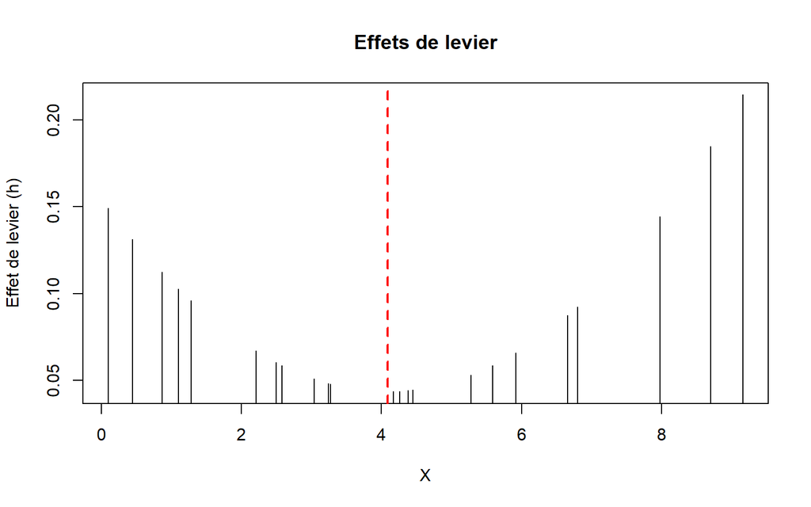

Figure 15.56: Effets levier vs X, pour les données du tableau Table 15.22.

```r
plot(hat$X,
     hat$Levier,
     type = 'h',
     main="Effets de levier",
     xlab="X",
     ylab="Effet de levier (h)")
abline(h=crith, lty=2, col="red", lwd=2)
abline(v=mean(hat$X), lty=2, lwd=2, col="red")
text(10, crith+0.02, paste("h-Crit = ", round(crith, 3)))
```

On note, de ces résultats, que les effets de levier pour chaque observation sont relativement faibles, et aucun n’atteint le seuil critique $3p/n=3(2)/23=0.26$. Cependant on voit clairement que l’effet de levier augmente en fonction de l’écart par rapport à la moyenne de la variable indépendante. Les données se trouvant dans les extrémités de la distribution de cette variable ont le **potentiel** d’influencer la régression. Cette influence se manifestera si la valeur résiduelle est également importante. Le graphique illustre la variation dans la valeur de $h_{ii}$ lorsque X s’éloigne de $\bar X$, dans une direction ou l’autre. Toute valeur de $h_{ii}$ dépassant le critère ($3p/n$) est susceptible d’influencer substanciellement la régression et devra être examinée de plus près.

À ce stade, nous disposons de deux mesures importantes: la valeur résiduelle, standardisée ou non, et $h_{ii}$, l’effet de levier. Nous avons vu qu’une valeur résiduelle importante n’affecte pas nécessairement la régression, et qu’un effet de levier important ne s’exerce pas nécessairement non plus. C’est la combinaison de ces deux conditions qui risque de causer des problèmes: une donnée présentant une grande valeur résiduelle **et** un effet de levier important risque d’avoir une grande **influence** sur la régression. Et on peut quantifier cette influence, mais avant de le faire, revenons sur la notion de valeur résiduelle pour en introduire une nouvelle variété: le **résidu Studentisé interne** (*‘Studentized Residual’*)

#### 15.12.1.7 Résidu Studentisé interne

Les valeurs résiduelles standardisées, utilisées jusqu’à maintenant, ont l’avantage de la simplicité, mais le défaut d’un lien entre le résidu et l’erreur-standard d’estimation (numérateur et dénominateur, respectivement). Pour contourner ce problème, il conviendra de remplacer l’erreur-standard d’estimation (dénominateur commun à tous les résidus standardisés) par l’erreur-standard du résidu lui-même, défini par l’équation Équation 15.52:

$$e_{Std}=\frac{e_i}{s_{(e_i)}}=\frac{e_i}{\sqrt{CM_{Résidu}(1-h_{ii})}} \tag{15.52}$$

L’erreur-standard d’un résidu est pondérée en fonction de l’effet de levier de ce dernier, ce qui le rend unique et spécifique: la dépendance entre le numérateur et le dénominateur est éliminée.

Sous R, la fonction **ResStud()** (Listing 15.17) effectue le travail nécessaire. Pour les données du tableau Table 15.22, on obtient le tableau Table 15.28:

```r
reg1 <- lm(y~x, data=dat)
resstudent <- ResStud(reg1)
h4 <- hatvalues(reg1)
res <- data.frame(dat,
                  reg1$residuals,
                  reg1$residuals / summary(reg1)$sigma,
                  resstudent,
                  h4)
colnames(res) <- c("ID","X", "Y", "Res.NonStd",
                   "Res.Std.", "Res.Stud.", "Levier")
res %>%
  kbl(caption="Valeurs résiduelles", digits=3) %>%
  kable_styling(bootstrap_options = c("striped", "hover", "condensed"),
                full_width=FALSE) %>%
  row_spec(21, bold=TRUE, background="#7FFFD0")
```

Table 15.28: Ensemble des données et des valeurs résiduelles (non standardisées, standardisées et studentisées), et de l’effet de levier pour les données du tableau Table 15.22.

Valeurs résiduelles

| ID | X | Y | Res.NonStd | Res.Std. | Res.Stud. | Levier |
| --- | --- | --- | --- | --- | --- | --- |
| 1 | 0.10 | 0.07 | -7.527 | -1.103 | -1.196 | 0.149 |
| 2 | 0.45 | 4.17 | -4.805 | -0.704 | -0.755 | 0.131 |
| 3 | 0.87 | 25.95 | 15.321 | 2.245 | 2.382 | 0.112 |
| 4 | 1.10 | 6.57 | -4.965 | -0.727 | -0.768 | 0.103 |
| 5 | 1.28 | 13.81 | 1.567 | 0.230 | 0.241 | 0.096 |
| 6 | 2.21 | 11.45 | -4.455 | -0.653 | -0.676 | 0.067 |
| 7 | 2.50 | 12.96 | -4.087 | -0.599 | -0.618 | 0.060 |
| 8 | 3.04 | 20.16 | 0.987 | 0.145 | 0.148 | 0.051 |
| 9 | 3.24 | 17.56 | -2.400 | -0.352 | -0.360 | 0.048 |
| 10 | 4.45 | 26.03 | 1.306 | 0.191 | 0.196 | 0.044 |
| 11 | 4.17 | 22.76 | -0.862 | -0.126 | -0.129 | 0.044 |
| 12 | 5.28 | 26.30 | -1.692 | -0.248 | -0.255 | 0.053 |
| 13 | 5.59 | 30.69 | 1.478 | 0.216 | 0.223 | 0.058 |
| 14 | 5.92 | 33.94 | 3.428 | 0.502 | 0.520 | 0.066 |
| 15 | 6.66 | 30.92 | -2.505 | -0.367 | -0.384 | 0.087 |
| 16 | 6.80 | 34.11 | 0.134 | 0.020 | 0.021 | 0.092 |
| 17 | 7.98 | 23.36 | -15.262 | -2.236 | -2.417 | 0.144 |
| 18 | 3.27 | 22.33 | 2.252 | 0.330 | 0.338 | 0.048 |
| 19 | 2.58 | 18.72 | 1.358 | 0.199 | 0.205 | 0.059 |
| 20 | 4.38 | 20.78 | -3.669 | -0.537 | -0.550 | 0.044 |
| 21 | 8.70 | 46.55 | 5.093 | 0.746 | 0.826 | 0.185 |
| 22 | 9.16 | 45.77 | 2.502 | 0.367 | 0.414 | 0.214 |
| 23 | 4.26 | 40.78 | 16.804 | 2.462 | 2.518 | 0.044 |

Les valeurs résiduelles studentisées sont évidemment plus élevées que les résidus standardisés, plus particulièrement pour les observations pour lesquelles l’effet de levier est important. La détection des cas susceptibles d’avoir une influence indue sur la régression en est donc facilitée.

#### 15.12.1.8 Mesure de l’influence

L’influence qu’une donnée peut avoir sur l’ensemble des résultats d’une régression peut s’évaluer de différentes manières. Dans le cas de la régression linéaire simple, nous nous limiterons à l’une d’elles: la **distance de Cook**. Cet indice est défini par l’équation Équation 15.53:

$$D_i=\left[\frac{e_i^2}{p CM_{Résidu}} \right ]\left[\frac{h_{ii}}{(1-h_{ii})^2} \right ] \tag{15.53}$$

Cette définition est claire quant à la nature de cet indice: c’est le produit d’une quantité fondée sur la valeur résiduelle et une quantité fondée sur l’effet de levier. Pour une valeur résiduelle ou un effet de levier nul, le coefficient d’influence (distance de Cook) est également nul. Pour qu’une donnée soit influente, ces deux portions doivent être élevées. Spécifiquement, $D_i$ évalue le changement moyen dans une valeur prédite $Y'$ si l’observation correspondante était omise de l’analyse. Un changement important serait indicateur d’une grande influence.

Il existe plusieurs opinions concernant l’interprétation de $D_i$, et il n’existe aucun consensus sur la valeur critique de cet indice permettant de distinguer les valeurs influentes de celles qui ne le sont pas. Cependant, un critère qui revient un peu plus souvent que d’autres propose qu’une donnée est influente si la distance de Cook correspondante est supérieure à $4/n$.

Plusieurs auteurs suggèrent que l’examen graphique est l’outil de choix dans ce cas: toute donnée dont la valeur de $D_i$ se démarque des autres devrait attirer l’attention et être examinée plus en détail. On pourra reprendre l’analyse en omettant la donnée suspecte, et évaluer son impact réel sur les différentes statistiques de régression.

La fonction **cooks.distance()** calcule $D_i$. Utilisant cette fonction sur les données du tableau Table 15.22, on l’ajoute au tableau Table 15.28, pour obtenir le tableau Table 15.29. En déployant les résultats dans un diagramme par points, on obtient la figure Figure 15.57.

```r
cd <- cooks.distance(reg4)
res$CookD <- cd
res %>%
  kbl(caption="Valeurs résiduelles", digits=3) %>%
  kable_styling(bootstrap_options = c("striped", "hover", "condensed"),
                full_width=FALSE) %>%
  row_spec(3, bold=TRUE, background="#7FFFD0") %>%
  row_spec(17, bold=TRUE, background="#7FFFD0")
```

Table 15.29: Ajout de la Distance de Cook aux mesures d’influence.

Valeurs résiduelles

| ID | X | Y | Res.NonStd | Res.Std. | Res.Stud. | Levier | CookD |
| --- | --- | --- | --- | --- | --- | --- | --- |
| 1 | 0.10 | 0.07 | -7.527 | -1.103 | -1.196 | 0.149 | 0.125 |
| 2 | 0.45 | 4.17 | -4.805 | -0.704 | -0.755 | 0.131 | 0.043 |
| 3 | 0.87 | 25.95 | 15.321 | 2.245 | 2.382 | 0.112 | 0.359 |
| 4 | 1.10 | 6.57 | -4.965 | -0.727 | -0.768 | 0.103 | 0.034 |
| 5 | 1.28 | 13.81 | 1.567 | 0.230 | 0.241 | 0.096 | 0.003 |
| 6 | 2.21 | 11.45 | -4.455 | -0.653 | -0.676 | 0.067 | 0.016 |
| 7 | 2.50 | 12.96 | -4.087 | -0.599 | -0.618 | 0.060 | 0.012 |
| 8 | 3.04 | 20.16 | 0.987 | 0.145 | 0.148 | 0.051 | 0.001 |
| 9 | 3.24 | 17.56 | -2.400 | -0.352 | -0.360 | 0.048 | 0.003 |
| 10 | 4.45 | 26.03 | 1.306 | 0.191 | 0.196 | 0.044 | 0.001 |
| 11 | 4.17 | 22.76 | -0.862 | -0.126 | -0.129 | 0.044 | 0.000 |
| 12 | 5.28 | 26.30 | -1.692 | -0.248 | -0.255 | 0.053 | 0.002 |
| 13 | 5.59 | 30.69 | 1.478 | 0.216 | 0.223 | 0.058 | 0.002 |
| 14 | 5.92 | 33.94 | 3.428 | 0.502 | 0.520 | 0.066 | 0.010 |
| 15 | 6.66 | 30.92 | -2.505 | -0.367 | -0.384 | 0.087 | 0.007 |
| 16 | 6.80 | 34.11 | 0.134 | 0.020 | 0.021 | 0.092 | 0.000 |
| 17 | 7.98 | 23.36 | -15.262 | -2.236 | -2.417 | 0.144 | 0.492 |
| 18 | 3.27 | 22.33 | 2.252 | 0.330 | 0.338 | 0.048 | 0.003 |
| 19 | 2.58 | 18.72 | 1.358 | 0.199 | 0.205 | 0.059 | 0.001 |
| 20 | 4.38 | 20.78 | -3.669 | -0.537 | -0.550 | 0.044 | 0.007 |
| 21 | 8.70 | 46.55 | 5.093 | 0.746 | 0.826 | 0.185 | 0.077 |
| 22 | 9.16 | 45.77 | 2.502 | 0.367 | 0.414 | 0.214 | 0.023 |
| 23 | 4.26 | 40.78 | 16.804 | 2.462 | 2.518 | 0.044 | 0.145 |

Les distances de Cook observées pour les observations 3 et 17 semblent suspectes.

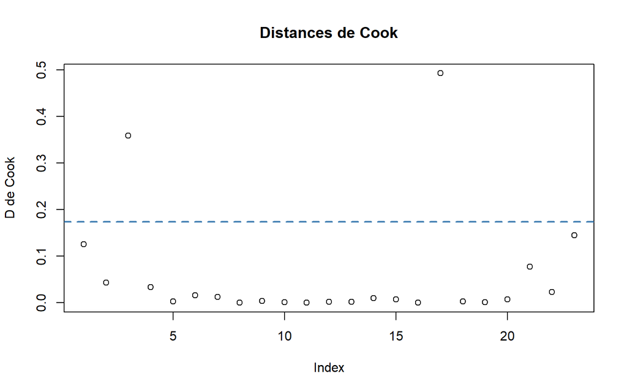

```r
cd <- cooks.distance(reg4)
n <- nrow(res)
plot(cd,
     main = "Distances de Cook",
     ylab = "D de Cook")
abline(h = 4/n, lty = 2, lwd=2, col = "steelblue")
```

Considérant le critère proposé, 4/n = 4/23 = 0.174, il semble que les observations ID#3 et ID#17 pourraient avoir une influence indue sur la régression.

#### 15.12.1.9 Valeur résiduelle avec omission (‘*Deleted Residual*’)

L’influence d’une donnée peut se vérifier si la valeur résiduelle (non-standardisée) $e_i$ change selon que l’observation $Y_i$ est incluse ou non dans l’analyse de régression. La logique derrière cette opération se résume ainsi:

- Si une observation a une grande influence, elle va attirer vers elle la droite de régression (comme la moyenne qui se déplace en direction d’une donnée extrême): la valeur résiduelle s’en trouve réduite.
- Si on enlève cette observation des données analysées, la droite de régression revient à une position où l’influence n’existe plus.
- Finalement, en prédisant Y à partir de l’équation de régression exempte d’influence, on obtient la valeur résiduelle avec omission: plus sa valeur est élevée, plus il y a indication que l’observation est influente.

Pour les données du tableau Table 15.22, on obtient la figure Figure 15.58, dont les données sont reproduites au tableau Table 15.30.

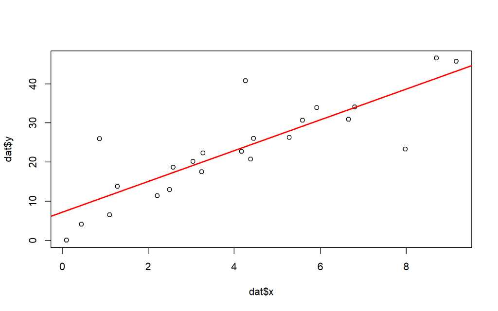

Figure 15.58: Valeurs résiduelles avec Omission

```r
reg4 <- lm(y~x, data=dat)
res0 <- reg4$residuals
plot(dat$x, dat$y)
abline(reg4, col="red", lwd=2)
```

```r
ryp <- vector()
for(i in 1:length(dat$x)){
  dd <- dat[-i, ]
  reg <- lm(y~x, data=dd)
  yp <- predict(reg, newdata=data.frame(dat[i,]))
  ryp[i] <- dat$y[i]-yp
}
res <- data.frame(dat, res0, ryp)
colnames(res) <- c("ID","X", "Y", "Res.Nstd.", "Res.Omis.")
res %>%
  kbl(caption="Valeurs résiduelles avec Omission", digits=3) %>%
  kable_styling(bootstrap_options = c("striped", "hover", "condensed"),
                full_width=FALSE)
```

Table 15.30: Valeurs résiduelles avec Omission

Valeurs résiduelles avec Omission

| ID | X | Y | Res.Nstd. | Res.Omis. |
| --- | --- | --- | --- | --- |
| 1 | 0.10 | 0.07 | -7.527 | -8.846 |
| 2 | 0.45 | 4.17 | -4.805 | -5.532 |
| 3 | 0.87 | 25.95 | 15.321 | 17.257 |
| 4 | 1.10 | 6.57 | -4.965 | -5.533 |
| 5 | 1.28 | 13.81 | 1.567 | 1.733 |
| 6 | 2.21 | 11.45 | -4.455 | -4.774 |
| 7 | 2.50 | 12.96 | -4.087 | -4.348 |
| 8 | 3.04 | 20.16 | 0.987 | 1.040 |
| 9 | 3.24 | 17.56 | -2.400 | -2.522 |
| 10 | 4.45 | 26.03 | 1.306 | 1.366 |
| 11 | 4.17 | 22.76 | -0.862 | -0.901 |
| 12 | 5.28 | 26.30 | -1.692 | -1.787 |
| 13 | 5.59 | 30.69 | 1.478 | 1.569 |
| 14 | 5.92 | 33.94 | 3.428 | 3.670 |
| 15 | 6.66 | 30.92 | -2.505 | -2.745 |
| 16 | 6.80 | 34.11 | 0.134 | 0.147 |
| 17 | 7.98 | 23.36 | -15.262 | -17.834 |
| 18 | 3.27 | 22.33 | 2.252 | 2.365 |
| 19 | 2.58 | 18.72 | 1.358 | 1.443 |
| 20 | 4.38 | 20.78 | -3.669 | -3.838 |
| 21 | 8.70 | 46.55 | 5.093 | 6.248 |
| 22 | 9.16 | 45.77 | 2.502 | 3.185 |
| 23 | 4.26 | 40.78 | 16.804 | 17.571 |

De cet exercice, on trouve que les observations ID#3, ID#17 etID#23 pourraient avoir une influence sur la régression. En effet, le simple fait de les retirer produit un changement important (au moins en apparence!) dans les valeurs résiduelles. Par contre, ces valeurs ne sont pas standardisées, ce qui ne nous permet pas de spécifier des critères fermes permettant de distinguer les valeurs influentes de celles qui ne le sont pas.

#### 15.12.1.10 Valeur résiduelle studentisée externe (*Studentized deleted residuals*)

Les valeurs résiduelles avec omission ont l’avantage de la simplicité, mais on leur préférera généralement une saveur standardisée qui offre plus d’avantage sur le plan de l’interprétation: les **valeurs résiduelles studentisées avec omission** (ou externe). On définit cette quantité par l’équation Équation 15.54:

$$e_{Std.D}=\frac{e_i}{s_{(e_{(i)})}}=\frac{e_i}{\sqrt{CM_{Résidu_{(i)}}(1-h_{ii})}} \tag{15.54}$$

La différence entre cette version et les résidus studentisés présentés dans les paragraphes précédents est que $CM_{Résidu}$ est calculé après avoir omis l’observation $i$ de l’analyse. Une formulation alternative, mais équivalente, défini ces valeurs résiduelles à partir des résidus studentisés (équation Équation 15.55):

```r
res.stud.del <- MASS::studres(reg4) # Studentized Deleted Residuals
resstudent <- ResStud(reg4)
h4 <- hatvalues(reg4)
cd <- cooks.distance(reg4)
res <- data.frame(dat,
                  reg4$residuals,
                  reg4$residuals / summary(reg4)$sigma,
                  resstudent,
                  res.stud.del,
                  h4,
                  cd)
colnames(res) <- c("ID","X", "Y", "Res.NonStd", "Res.Std.",
                   "Res.Stud.", "Res.Stud.Del", "Levier", "D.Cook")
res %>%
  kbl(caption="Valeurs résiduelles", digits=3) %>%
  kable_styling(bootstrap_options = c("striped", "hover", "condensed"),
                full_width=FALSE) %>%
  row_spec(3, bold=TRUE, background="#7FFFD0") %>%
  row_spec(17, bold=TRUE, background="#7FFFD0")
```

Table 15.31: Valeurs résiduelles studentisées, avec Omission

Valeurs résiduelles

| ID | X | Y | Res.NonStd | Res.Std. | Res.Stud. | Res.Stud.Del | Levier | D.Cook |
| --- | --- | --- | --- | --- | --- | --- | --- | --- |
| 1 | 0.10 | 0.07 | -7.527 | -1.103 | -1.196 | -1.209 | 0.149 | 0.125 |
| 2 | 0.45 | 4.17 | -4.805 | -0.704 | -0.755 | -0.747 | 0.131 | 0.043 |
| 3 | 0.87 | 25.95 | 15.321 | 2.245 | 2.382 | 2.722 | 0.112 | 0.359 |
| 4 | 1.10 | 6.57 | -4.965 | -0.727 | -0.768 | -0.760 | 0.103 | 0.034 |
| 5 | 1.28 | 13.81 | 1.567 | 0.230 | 0.241 | 0.236 | 0.096 | 0.003 |
| 6 | 2.21 | 11.45 | -4.455 | -0.653 | -0.676 | -0.667 | 0.067 | 0.016 |
| 7 | 2.50 | 12.96 | -4.087 | -0.599 | -0.618 | -0.608 | 0.060 | 0.012 |
| 8 | 3.04 | 20.16 | 0.987 | 0.145 | 0.148 | 0.145 | 0.051 | 0.001 |
| 9 | 3.24 | 17.56 | -2.400 | -0.352 | -0.360 | -0.353 | 0.048 | 0.003 |
| 10 | 4.45 | 26.03 | 1.306 | 0.191 | 0.196 | 0.191 | 0.044 | 0.001 |
| 11 | 4.17 | 22.76 | -0.862 | -0.126 | -0.129 | -0.126 | 0.044 | 0.000 |
| 12 | 5.28 | 26.30 | -1.692 | -0.248 | -0.255 | -0.249 | 0.053 | 0.002 |
| 13 | 5.59 | 30.69 | 1.478 | 0.216 | 0.223 | 0.218 | 0.058 | 0.002 |
| 14 | 5.92 | 33.94 | 3.428 | 0.502 | 0.520 | 0.510 | 0.066 | 0.010 |
| 15 | 6.66 | 30.92 | -2.505 | -0.367 | -0.384 | -0.376 | 0.087 | 0.007 |
| 16 | 6.80 | 34.11 | 0.134 | 0.020 | 0.021 | 0.020 | 0.092 | 0.000 |
| 17 | 7.98 | 23.36 | -15.262 | -2.236 | -2.417 | -2.777 | 0.144 | 0.492 |
| 18 | 3.27 | 22.33 | 2.252 | 0.330 | 0.338 | 0.331 | 0.048 | 0.003 |
| 19 | 2.58 | 18.72 | 1.358 | 0.199 | 0.205 | 0.200 | 0.059 | 0.001 |
| 20 | 4.38 | 20.78 | -3.669 | -0.537 | -0.550 | -0.540 | 0.044 | 0.007 |
| 21 | 8.70 | 46.55 | 5.093 | 0.746 | 0.826 | 0.820 | 0.185 | 0.077 |
| 22 | 9.16 | 45.77 | 2.502 | 0.367 | 0.414 | 0.405 | 0.214 | 0.023 |
| 23 | 4.26 | 40.78 | 16.804 | 2.462 | 2.518 | 2.940 | 0.044 | 0.145 |

De ce tableau, on constate que toutes les mesures et saveurs de valeurs résiduelles portent à croire que les observations ID#3 et ID#17 exercent une influence importante sur les paramètres de la régression. On peut noter également que les observations ID #21 et ID#22 ont des effets de levier importants, sans que leur influence soit manifeste.

La librairie **olsrr** offre une gamme de fonctions permettant la visualisation des différents indices d’influence présentés dans les paragraphes précédents. Par exemple, le diagramme en barres représentant les distances de Cook est produit à l’aide de la fonction **ols_plot_cooksd_bar()** (figure Figure 15.59):

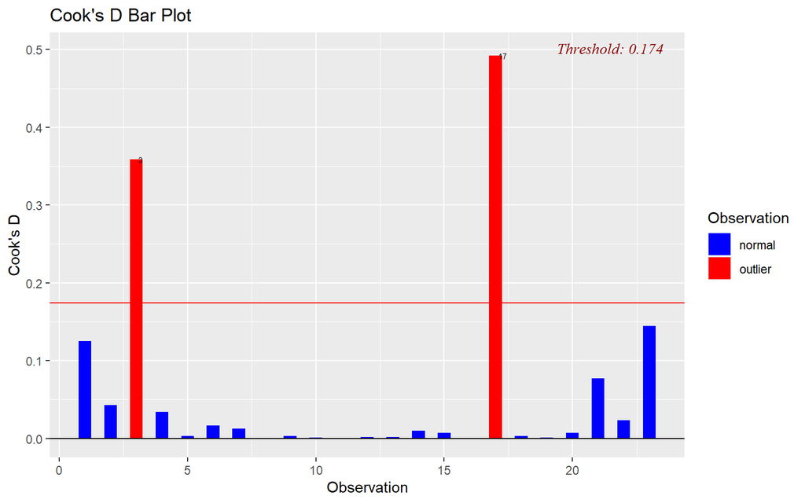

Figure 15.59: Diagramme en barres: Distances de Cook

```r
olsrr::ols_plot_cooksd_bar(reg4)
```

L’influence des observations ID#3 et ID#17 est immédiatement apparente dans de diagramme..

De la même manière, la fonction **ols_plot_resid_stud()** représente graphiquement les résidus studentisés externes (figure Figure 15.60):

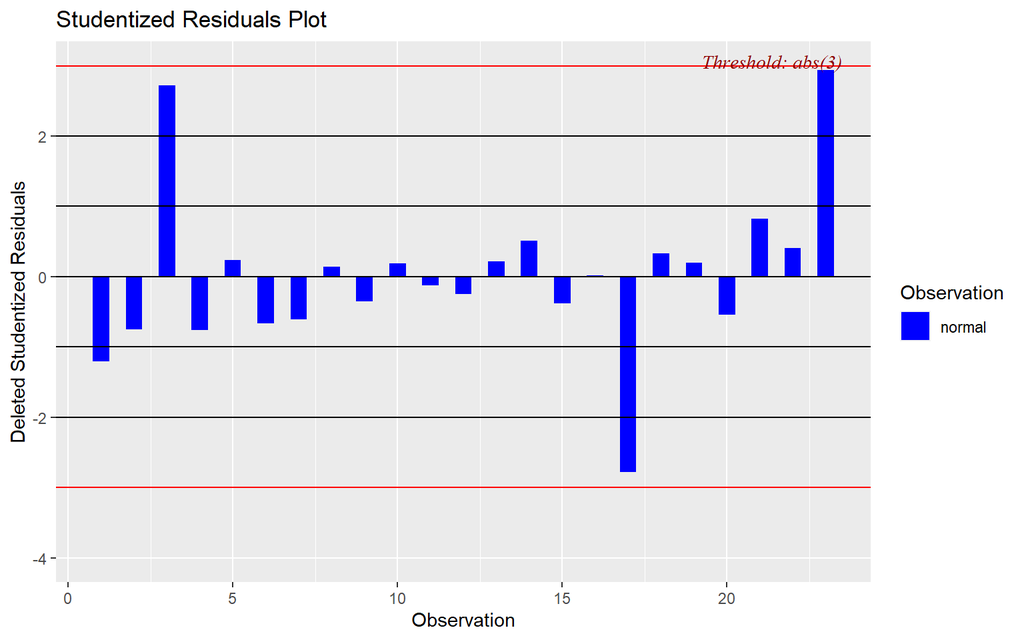

Figure 15.60: Diagramme des valeurs résiduelles Studentisées Externes

```r
ols_plot_resid_stud(reg4)
```

La fonction **ols_plot_resid_stand()** effectue le même travail pour les valeurs résiduelles studentisées internes (Figure 15.61):

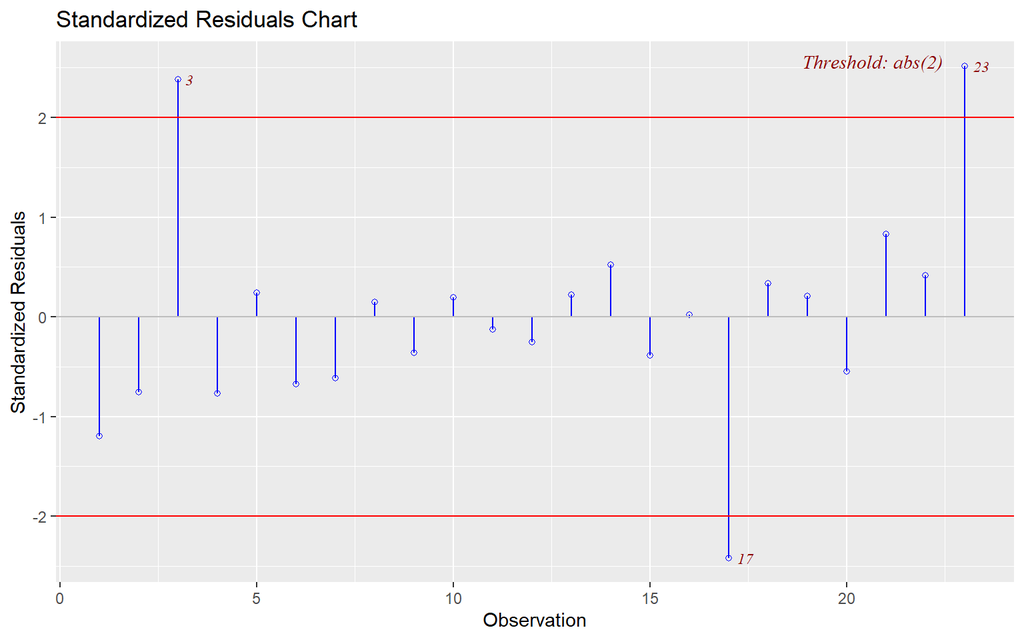

Figure 15.61: Diagramme des valeurs résiduelles Studentisées Internes

```r
ols_plot_resid_stand(reg4)
```

La fonction **ols_plot_resid_lev()** permet de visualiser les valeurs résiduelles et les effets de levier simultanément (Figure 15.62):

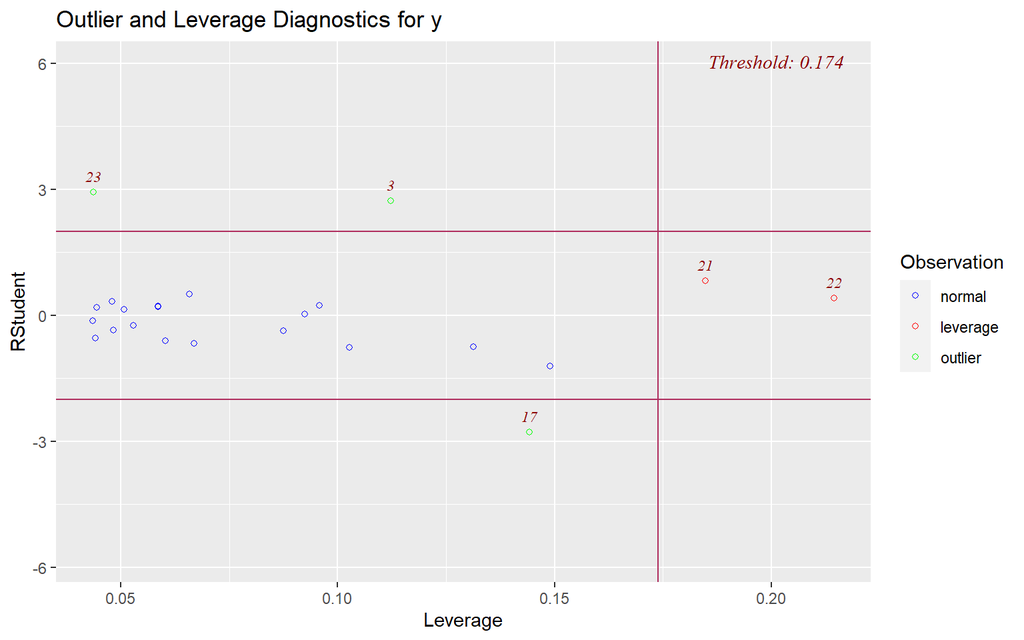

Figure 15.62: Diagramme des valeurs résiduelles vs Effets de levier

```r
ols_plot_resid_lev(reg4)
```

Finalement, la fonction **ols_plot_resid_stud_fit()** produit un diagramme de dispersion illustrant la relation entre les valeurs résiduelles studentisées externes et les valeurs prédites (figure Figure 15.63):

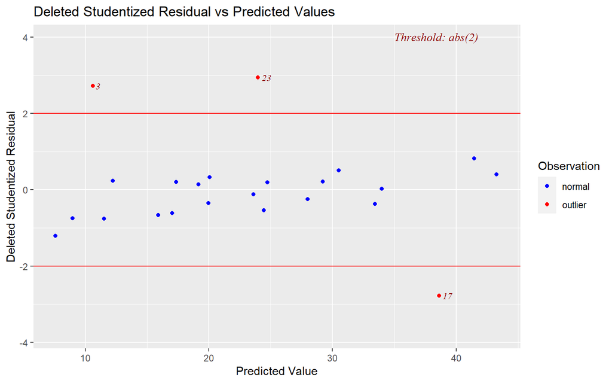

Figure 15.63: Diagramme des valeurs résiduelles vs valeurs prédites

```r
ols_plot_resid_stud_fit(reg4)
```

### 15.12.2 Examen du respect des postulats: performance::check_model()

La librairie **performance** permet l’examen graphique des principaux postulats. De cette librairie, il faut mentionner la fonction **check_model()**. Pour les données analysées plus haut, on obtient l’ensemble de figures Figure 15.64:

```
#> Not enough model terms in the conditional part of the model to check for
#>   multicollinearity.
```

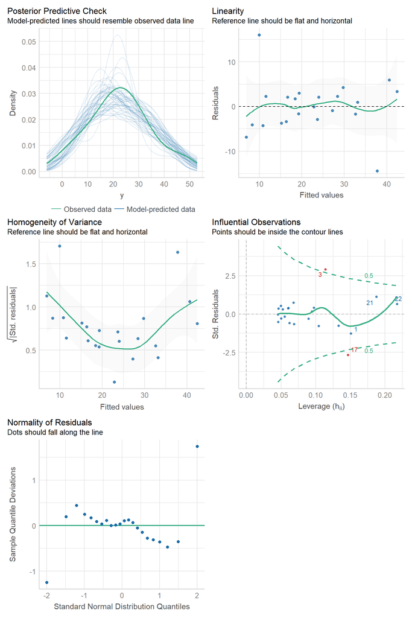

Figure 15.64: Analyse graphique des résidus à l’aide de la fonction **check_model()** de la librairie **performance**.

```r
performance::check_model(reg,
                         panel=TRUE,
                         alpha=0.05,
                         verbose=TRUE)
```

## 15.13 Conclusion

Dans ce chapitre, nous avons introduit les fondements de la modélisation statistique en décrivant le modèle le plus simple que l’on puisse proposer: le modèle de régression linéaire. Quoique simple, n’impliquant qu’une seule relation entre deux variables, il faut noter les embûches qui peuvent se présenter lors de son application. La validité du modèle repose sur plusieurs postulats dont le non-respect risque d’invalider toute conclusion que l’on pourrait en tirer. Une analyse de régression ne peut jamais se terminer par la détermination de la droite de régression et les tests de signification qui la concerne. Un examen approfondi de l’ajustement des données par l’analyse des résidus est une composante essentielle et incontournable de toute analyse de régression.

## 15.14 Appendices: Fonctions R

### 15.14.1 RegSim

Listing 15.1: Simulation de données bivariées

```sql
#' Simulation de données bivariées

RegSim <- function(nrep=10000, n=50, xb=20, sx=5, yb=40, sy=10, r=0.6){

  b0 <- vector()
  b1 <- vector()
  rxy <- vector()

  for(i in 1:nrep) {
    x1 = rnorm(n)
    y1 = r * x1 + sqrt(1-r^2)*rnorm(n)
    x <- x1*sx + xb
    y <- y1*sy + yb
    reg <- lm(y~x)
    rxy[i] <- cor(x,y)
    b0[i] <- reg$coefficients[1]
    b1[i] <- reg$coefficients[2]
  }
  return(list(rxy=rxy, b0=b0, b1=b1))
}
```

### 15.14.2 Cortest

Listing 15.2: Vérification d’hypothèses concernant les corrélations

```sql
#' Vérification d'hypothèses concernant les corrélations

CorTest <- function(r, n){
  if(length(r)!=length(n)){
    stop:"Les arguments doivent être de même longueur!"}
  if(length(r)==1){
    stop:"Les arguments doivent être des vecteurs de longueur supérieure à 1!"}
  z <- r2z(r)
  if(length(r)==2){
      Z <- (z[1]-z[2]) / sqrt(sum(1/(n-3)))
      p <- 2* (1 - pnorm(Z)) # Test bilatéral
  }else{
      chi2 <- sum((n-3) * z^2) - (sum((n-3) * z)^2 / sum(n-3))
      dl <- length(r) - 1
      p <- pchisq(chi2, dl, lower.tail=FALSE)
  }
  if(length(r)==2){
    cat("Z = ", Z, "   p = ", p)
  }else{
    cat("Chi2 = ", chi2, "   p = ", p)
  }
}
```

### 15.14.3 R_CI

Listing 15.3: Intervalle de confiance d’une corrélation: Simulation

```sql
#' Intervalle de confiance d'une corrélation: Simulation

#' Intervalle de confiance d'une corrélation - Simulation
#' Échantillons tirés d'une distribution normale
#' @param r = Corrélation au niveau de la population
#' @param n = Taille de l'échantillon
#' @param nrep = Nombre de ré-échantillonnages
#' @param nconf = Niveau de confiance
#' @export

R_CI <- function(r=0.36, n=50, nrep=100000, conf=95){

z   = .5*log((1+r)/(1-r))
se  = 1/sqrt(n-3)
zvec= rnorm(nrep)*se+z
ivec= (exp(2*zvec)-1)/(exp(2*zvec)+1)
low = (1-conf/100)/2
upp = ((1-conf/100)/2)+(conf/100)
LL  = quantile(ivec,low)
UL  = quantile(ivec,upp)
LL4 = format(LL,digits=3)
UL4 = format(UL,digits=3)

gr1 <- hist(ivec,
            breaks = "FD",
            plot = FALSE)
cuts <- cut(gr1$breaks, c(-Inf, LL, UL, Inf))
plot(gr1,
     main = "Distribution Empirique de r",
     col = c("red", "lightblue", "red")[cuts],
     freq=FALSE,
     xlab=paste("P[", LL4,"\u2264 r \u2264 ",UL4,"] = ",conf, "%"),
     ylab = "Densité",
     cex=0.4)

abline(v=mean(ivec), lty=2, lwd=2, col="#CC0000")
txt1 <- paste("Moyenne = ", round(mean(ivec), 3))
txt2 <- paste("Err.Std = ", round(sd(ivec), 3))
legend(ifelse(mean(ivec)>=0, "topleft", "topright"),
       legend = c(txt1, txt2),
       lty = 0:0,
       cex = 0.8,
       bg = "lightyellow")
}
```

### 15.14.4 r2z

Listing 15.4: Transformation de Fisher: R -> Z

```sql
#' Transformation de Fisher: R -> Z

#' Fisher Transformation: r to z
#' Argument: Correlation
#' Output: Fisher's z
#' @param r = correlation
#' @export
r2z <- function(r){
  if((sum(r<(-1) | r>1))!=0) stop("Corrélation invalide!")
  z <- 0.5 * log((1 + r)/(1 - r))
  return(z)
}
```

### 15.14.5 z2r

Listing 15.5: Transformation de Fisher: Z -> R

```sql
#' Transformation de Fisher: Z -> R

#' Fisher Transformation: z to r
#' Argument: z (can be a vector)
#' Output: r
#' @param z = Fisher's z
#' @export
z2r <- function(z){
  if((sum(z<(-10) | z>10))!=0) stop("Z invalide!")
  r <- (exp(2 * z) - 1)/(1 + exp(2 * z))
  return(r)
}
```

### 15.14.6 Z_CI

Listing 15.6: Simulation d’un intervalle de confiance pour Z (R transformé)

```sql
#' Simulation d'un intervalle de confiance pour Z (R transformé)

#' Intervalle de confiance: corrélation transformée en Z (Fisher) - Simulation
#' Échantillons tirés d'une distribution normale
#' @param r = Corrélation au niveau de la population
#' @param n = Taille de l'échantillon
#' @param nrep = Nombre de réplications
#' @param nconf = Niveau de confiance
#' @export

Z_CI <- function(r=0.36, n=50, nrep=100000, conf=95){

  z=.5*log((1+r)/(1-r))
  se=1/sqrt(n-3)
  zvec=rnorm(nrep)*se+z
  low=(1-conf/100)/2
  upp=((1-conf/100)/2)+(conf/100)
  LL=quantile(zvec,low)
  UL=quantile(zvec,upp)
  LL4=format(LL,digits=4)
  UL4=format(UL,digits=4)

  gr1 <- hist(zvec,
              breaks = "FD",
              plot = FALSE)
  cuts <- cut(gr1$breaks, c(-Inf, LL, UL, Inf))
  plot(gr1,
       main = "Distribution Empirique de Zxy",
       col = c("red", "lightblue", "red")[cuts],
       freq=FALSE,
       xlab=paste("P[", LL4,"\u2264 \u005A \u2264 ",UL4,"] = ",conf, "%"), cex=0.4)
  abline(v=mean(zvec), lty=2, lwd=2, col="#CC0000")
  txt1 <- paste("Moyenne = ", round(mean(zvec), 3))
  txt2 <- paste("Err.Std = ", round(sd(zvec), 3))
  legend("topleft",
         legend = c(txt1, txt2),
         lty = 0:0,
         cex = 0.8,
         bg = "lightyellow")
  return(zst <- c(mean(zvec), sd(zvec)))
}
```

### 15.14.7 PlotScat

Listing 15.7: Diagramme de dispersion et distributions marginales

```sql
#' Diagramme de dispersion et distributions marginales

# Plot scattergram with marginals
#
# x <- rnorm(1000)
# y <- x*0.80+rnorm(1000)*sqrt(1-0.8**2)
# x <- x * 15 + 100
# y <- y * 6 + 20
# r <- cor(x,y)

PlotScat <- function(x, y){
  require(ggplot2)
  require(ggExtra)

df <- data.frame(x, y)
reg <- lm(y~x, data=df)
b0 <- reg$coefficients[1]
b1 <- reg$coefficients[2]
eq = paste0("Y' = ", round(reg$coeff[2],4), " x X ", round(reg$coeff[1],4))
p <- ggplot(df, aes(x, y)) +
  geom_point() +
  theme_classic() +
  labs(x="X") +
  labs(y="Y") +
  geom_abline(intercept = reg$coeff[1], slope = reg$coeff[2], color="red", linewidth=1.3) +
  ggtitle(eq) +
  geom_hline(yintercept = mean(y), linetype="dashed", color="blue", linewidth=1.2) +
  geom_vline(xintercept = mean(x), linetype="dashed", color="blue", linewidth=1.2) +
  geom_point(aes(x=mean(x), y=mean(y)), colour="yellow", size=5) +
  geom_text(x=2.6, y=-0.3, label="Moyenne Y") +
  geom_text(x=0, y=3.2, label="Moyenne X") +
  geom_text(x=-2, y=3, label=paste("R = ", round(r,3)), size=6)
ggExtra::ggMarginal(p, type = "densigram", col="black", fill="#7FFFD0")
}
```

### 15.14.8 GraphDist

Listing 15.8: Distribution d’échantillonnage de diverses statistiques

```sql
#' Distribution d'échantillonnage de diverses statistiques

#'Graph Sampling Distribution
#'
#'@param xb vector of sampling statistics
#'@param nc scalar value: Confidence level (default = 0.95)
#'@param parm character value: name of the estimated parameter (default = 'Mean')
#'@examples
#'xb <- rnorm(1000,100,2)
#'GraphDist(xb,nc=0.99,parm='Medians')
#'@export

GraphDist <- function(xb, nc = 0.95, parm = "Moyennes") {
    intc <- quantile(xb,
                     c(0.5 * (1 - nc), nc + 0.5 * (1 - nc)))  # Calcul des percentiles
    gr1 <- hist(xb, breaks = "FD", plot = FALSE)
    cuts <- cut(gr1$breaks, c(-Inf, intc[1], intc[2], Inf))
    maintit <- paste("Distribution des", parm)
    plot(gr1,
         main = maintit,
         xlab = parm,
         col = c("red", "cadetblue1", "red")[cuts])
    txt1 <- paste("Moyenne    = ", round(mean(xb), 3))
    txt2 <- paste("Err.Std.   = ", round(sd(xb), 3))
    legend("topleft",
           legend = c(txt1, txt2),
           lty = 0:0,
           cex = 0.8,
           bg = "lightgreen")
    txt3 <- paste("IC(", nc * 100, "%) = [", round(intc[1], 3), ",", round(intc[2], 3), "]")
    legend("topright",
           legend = c(txt3),
           lty = 0:0, cex =
             0.8,
           bg = "cadetblue1")
}
```

### 15.14.9 PRESS

Listing 15.9: Calcul de la statistique PRESS (’Predictive Residual Sum of Squares

```sql
#' @title PRESS
#' @author Thomas Hopper
#' @description Returns the PRESS statistic (predictive residual sum of squares).
#'              Useful for evaluating predictive power of regression models.
#' @param linear.model A linear regression model (class 'lm'). Required.
#'
PRESS <- function(linear.model) {
  pr <- residuals(linear.model)/(1-lm.influence(linear.model)$hat)
  PRESS <- sum(pr^2)
  return(PRESS)
}
```

### 15.14.10 pred_r2

Listing 15.10: Calcul du R2 prédictif

```sql
#' @title Predictive R-squared
#' @author Thomas Hopper
#' @description returns the predictive r-squared. Requires the function PRESS()
#' @param linear.model A linear regression model (class 'lm'). Required.
#'
pred_r2 <- function(linear.model) {
  lm.anova <- anova(linear.model)
  tss <- sum(lm.anova$'Sum Sq')
  r2pr <- 1-PRESS(linear.model)/(tss)
  return(r2pr)
}
```

### 15.14.11 AdjustMeas

Listing 15.11: Calcul des différentes mesures de qualité d’ajustement

```sql
AdjustMeas <- function(VD, VI){
  if(!(length(VD)==length(VI))){stop:"Les vecteurs doivent être de mêmes longueurs!"}
  model <- lm(VD~VI)
  n <- length(VD)
  k <- 1
  res <-  model$residuals
  r2 <- cor(VD, VI)^2
  r2adj <- 1 - ((1-r2) * (n-1)) / (n - k - 1)
  press <- PRESS(model)
  r2pred <- pred_r2(model)
  mae <-  mean(abs(res))
  mse <-  mean((res)^2)
  rmse <- sqrt(mse)
  mape <- 100 * sum(abs(res / VD)) / n
  mpe <-  100 * sum(res / VD) / n
  out <- list(model, r2, r2adj, press, r2pred, mae, mse, rmse, mape, mpe)
  return(out)
}
```

### 15.14.12 ConfBand

Listing 15.12: Bande de confiance pour la régression linéaire

```sql
ConfBand <- function(x, y, test=0, conf.lev=0.95){
  new <- data.frame(x=c(test))
  n <- length(x)
  cl <- (1-conf.lev)/2 + conf.lev
  reg <- lm(y ~ x)
  yp <- reg$fitted.values
  aov <- anova(reg)
  CMe <- aov$`Mean Sq`[2]
  IntBand <- predict(reg, newdata=new) +
    c(-1, 1) * rep(qt(cl, n-2)) *
    sqrt(CMe * (1/n + ((test-mean(x))^2)/ ((n-1)*var(x))))
  IntPred <- predict(reg, newdata=new) +
    c(-1, 1) * rep(qt(cl, n-2)) *
    sqrt(CMe * (1 + 1/n + ((test-mean(x))^2)/ ((n-1)*var(x))))
  return(list(IntBand, IntPred))
}
```

### 15.14.13 RegBandPlot

Listing 15.13: Bande de confiance pour la régression linéaire

```sql
RegBandPlot <- function(x, y, type = c("confidence", "prediction", "both"), conflev = 0.95){
  options(warn=-1)
  if(length(x) != length(y)) {stop("X et Y sont de longueurs différentes!")
                              return(NULL)}
  if(type == "confidence"){txt <- " de confiance"
    } else if (type == "prediction"){txt <- " de prédiction"
    } else {txt <- " de confiance et de prédiction"}

  df <- data.frame(x, y)
  model <- lm(y ~ x, data = df)

  predictions <- predict(model, interval = "prediction", level = conflev)
  confIntervl <- predict(model, interval = "confidence", level = conflev)

  df <- data.frame(cbind(df, predictions, confIntervl[, 2:3]))
  colnames(df) <- c("x", "y", "fit", "lwrPred", "uprPred", "lwrConf", "uprConf")

  gg <- ggplot(df, aes(x = x, y = y)) +
        geom_point(color = "blue") +
        geom_line(aes(y = predict(model, newdata = df)),
                  color = "red",
                  linetype = "dashed") +
        labs(x = "X",
             y = "Y",
             title = paste("Droite de régression avec bandes \n", txt)) +
        theme_classic()

  if(type == "confidence" | type == "both"){
    gg <- gg + geom_ribbon(data = df,
                           aes(x = x, ymin = lwrConf, ymax = uprConf),
                           fill = "blue",
                           alpha = 0.2) }

  if(type == "prediction" | type == "both"){
    gg <- gg + geom_ribbon(data = df,
                           aes(x = x, ymin = lwrPred, ymax = uprPred),
                           fill = "green",
                           alpha = 0.2) }

    print(gg)
    out <- list(data = df, grf = gg)
  return(out)
}
```

### 15.14.14 RegInterval

Listing 15.14: Bande de confiance pour la régression linéaire, incluant le tableau

```sql
RegInterval <- function(X, Y){
  data <- data.frame(X = X, Y = Y)

  reg <- lm(Y ~ X, data = data)

  confid <- predict(reg, interval = "confidence")
  predictions <- suppressWarnings(predict(reg, interval = "predict"))

  ConfTbl <- cbind(data, as.data.frame(predictions), confid[, 2:3])
  colnames(ConfTbl) <- c("X", "Y", "Y_Pred", "Pred_Inf", "Pred_Sup", "Conf_Inf", "Conf_Sup")

  p <- ggplot(ConfTbl, aes(x = X, y = Y)) +
    geom_point() +
    stat_smooth(method = lm) +
    geom_line(aes(y = Pred_Inf), col = "coral2", linetype = "dashed") +
    geom_line(aes(y = Pred_Sup), col = "coral2", linetype = "dashed") +
    ggtitle("Bande de Confiance (95%) et Intervalle de Prédiction")

  out =  list(grf = p, table = ConfTbl)
  return(out)
}
```

### 15.14.15 simulate_simpson

Listing 15.15: Simulation du Paradoxe de Simpson

```sql
#' Simpson's paradox dataset simulation
#'
#' @inheritParams bayestestR::simulate_correlation
#' @param n The number of observations for each group to be generated.
#' @param groups Number of groups.
#' @param difference Difference between groups.
#'
#' @return A dataset.
#'
#' @examples
#' data <- simulate_simpson(n = 100, groups = 5, r = 0.5)
#'
#' ggplot(data, aes(x = V1, y = V2)) +
#'   geom_point(aes(color = Group)) +
#'   geom_smooth(aes(color = Group), method = "lm") +
#'   geom_smooth(method = "lm")
#' @export
simulate_simpson <- function(n = 100, r = 0.5, groups = 5, difference = 1) {
  data <- data.frame()
  for (i in 1:groups) {
    dat <- bayestestR::simulate_correlation(n = n, r = r)
    dat$V1 <- dat$V1 + difference * i # (i * -sign(r))
    dat$V2 <- dat$V2 + difference * (i * -sign(r))
    dat$Group <- LETTERS[i]
    data <- rbind(data, dat)
  }
  return(data)
}
```

### 15.14.16 simulate_simpson2

Listing 15.16: Simulation du Paradoxe de Simpson

```sql
simulate_simpson2 <- function(n = 100, r = -0.5, groups = 5, difference = 1) {
  data <- data.frame()
  for (i in 1:groups) {
    dat <- bayestestR::simulate_correlation(n = n, r = runif(1, -0.7, 0.7))
    dat$V1 <- dat$V1 + difference * i # (i * -sign(r))
    dat$V2 <- dat$V2 + difference * (i * -sign(r))
    dat$Group <- LETTERS[i]
    data <- rbind(data, dat)
  }
  return(data)
}
```

### 15.14.17 Résidus Studentisés Internes

Listing 15.17: Calcul des Résidus Internes de Student

```sql
# Calcul des valeurs résiduelles 'studentisées' interne
ResStud <- function(model){
  if(!is(model, "lm")){stop: "Classe incorrecte: utilisez lm() au préalable."}
  res <- model$residuals
  CMerr <- anova(model)$`Mean Sq`
  res_stud <- res / (sqrt(CMerr[2] * (1 - hatvalues(model))))
  return(res_stud)
}
```

### 15.14.18 CorComb

Listing 15.18: Calcul d’une corrélation commune (groupes multiples)

```sql
CorComb <- function(r, n){
  if(length(r)!=length(n)){
    stop:"Les arguments doivent être de même longueur!"}
  if(length(r)==1){
    stop:"Les arguments doivent être des vecteurs de longueur supérieure à 1!"}
  zw <- sum(r2z(r) * (n - 3)) / sum(n - 3)
  rho = (exp(2 * zw)-1) / (exp(2 * zw)+1)
  cat("Rho = ", rho)
}
```